# **Cocoa Artesanal: Colombian and Global Cocoa Market Analysis with R and SQL**

Juan Veira

September 2025 – March 2026

# **Ask**

## **About**

**Cocoa Artesanal** creates handcrafted, premium chocolate products for those seeking an exclusive sensory experience. Specializing in chocolates for exceptional occasions, the brand offers unique designs and artisanal craftsmanship that go beyond the traditional mass market.

Each piece is thoughtfully crafted to elevate the luxury of chocolate whether for personal indulgence, high-end gifting, or corporate events that aim to bring a refined and memorable experience.

To support sustainable growth, the Founder is seeking a data-driven approach to understanding the global and local market dynamics that influence the business.

## **Key stakeholders**

- **Co-founder and Chief Creative Officer**: responsible for handcrafted product design and master production.
- **Co-founder and Business Strategist**: focused on capital investment and long-term market vision.
- **Co-founder and Head of Operations and Finance**: manages production costs, accounting, and internal budgeting.

## **Guiding questions**

- What are the key trends in the cocoa and Chocolate markets in the last 10 years?
- How can these trends inform Cocoa Artesanal business decisions?
- How do market fluctuations influence the purchasing and production cycles?

## **Business task**

> **Determine how the Global and Colombian cocoa markets behave, and how price fluctuations transmit into the chocolate market, in order to optimize purchasing and production cycles for a chocolate business.**

# **Prepare**

## **Data Sources & Strategy**

To build a comprehensive view of the cocoa market, I integrated data from several international and national institutions. My goal was to bridge the gap between global market trends and the local Colombian context.

### **Market Pricing & Economic Indicators**

I monitored price fluctuations and inflationary pressures using three primary lenses:

- **Global Cocoa Prices:** Sourced from the **International Monetary Fund (IMF) via FRED**, providing a benchmark for international metric ton pricing.
- **Colombian Cocoa Prices:** Obtained from **Agronet (Ministry of Agriculture)** to track how national purchase prices align with global trends.
- **Economic Drivers:** To account for currency volatility and manufacturing costs, I integrated the **Market Representative Rate (TRM)** from **Banrep** and the **Producer Price Index (PPI)** for chocolate manufacturing from the **U.S. Bureau of Labor Statistics**.

### **Defining Variables**

One of the initial challenges I faced was selecting a data source that effectively measured chocolate market behavior from a business perspective. My original intent was to utilize internal sales data; however, obtaining such datasets proved difficult, likely due to confidentiality constraints and the competitive nature of the industry.

Early in the process, I identified export and import data as a strong alternative data source. While trade flows are not the same as direct retail sales, they offer a reliable proxy for analyzing the broader market trends this project aims to evaluate.

After selecting this dataset, I identified the relevant product classifications, which led me to the following **HS codes (Harmonized System)** an internationally recognized and standardized system for classifying traded goods aligned with Artisanal chocolate products:

- **HS 180631**: Chocolate and other food preparations containing cocoa — filled (e.g., pralines, filled bars).
- **HS 180632**: Chocolate and other food preparations containing cocoa — not filled (e.g., standard chocolate bars, chips).

### **Detailed Source Reference**

| Category | Data Point | Source |
| --- | --- | --- |
| **Global Price** | Price per Metric Ton (USD) | [IMF via FRED](https://fred.stlouisfed.org/series/PCOCOUSDM) |
| **Colombian Price** | Weekly Reference Purchase Price | [Agronet](https://agronet.gov.co/noticias) |
| **Trade (Annual)** | Export Value (HS 1806) | [WITS / World Bank](https://wits.worldbank.org/) |
| **Trade (Monthly)** | Monthly Trade Flows (HS 180631/32) | [UN Comtrade+](https://comtradeplus.un.org/) |
| **Currency** | TRM (COP to USD) | [Banco de la República de Colombia](https://suameca.banrep.gov.co/estadisticas-economicas/informacionSerie/1/tasa_cambio_peso_colombiano_trm_dolar_usd) |
| **Industry Index** | Producer Price Index (PPI) | [BLS via FRED](https://fred.stlouisfed.org/series/PCU3113513113514) |

## **Data Integrity & ROCC Evaluation**

A crucial step in this project was ensuring the integrity and ethical use of the data. I evaluated all sources using the **ROCC framework** (Reliable, Original, Comprehensive, and Current) to guarantee the findings are both credible and actionable.

### **Privacy and Accessibility**

Security and ethics were at the forefront of the data acquisition process:

- **Public Accountability:** All datasets were sourced from official national and international institutions, ensuring they are **publicly available** and transparent.
- **Data Privacy:** The analysis contains no personal or sensitive information, maintaining a 100% anonymized workflow.
- **Licensing:** All data is used under licenses that permit non-commercial and educational use with proper attribution.

### **Quality Assurance**

To transition from “raw data” to “analytical insights,” I performed an preliminary audit of the sources (FRED, Agronet, and WITS):

- **Metadata Review:** I examined the underlying metadata to ensure a clear understanding of data definitions and collection methods.
- **Validation Checks:** I conducted initial scans to identify and address missing values, outliers, and potential currency mismatches specifically ensuring that global USD benchmarks were correctly aligned with local Colombian Peso (COP) figures.

### **Data Limitations & Pre-processing**

During the preliminary audit, I identified four key structural challenges that required specific data engineering to ensure the final analysis was accurate and cohesive:

- **Unit & Currency Standardization:** The raw datasets utilized different scales (COP/kg vs. USD/ton). I developed a conversion workflow to standardize all financial metrics, allowing for a direct “apples-to-apples” comparison between local production costs and global market prices.
- **Temporal Alignment:** Because the Colombian cocoa data was reported weekly while trade data was reported monthly, I performed a **temporal aggregation**. By grouping the weekly data into monthly averages.
- **Schema Integration:** Trade data was fragmented across multiple years and specific HS codes. I executed a series of data joins and unions to create a unified dataset that captures the full scope of Colombian chocolate exports.
- **Establishing a Common Timeline:** Since the timeframes of the various sources did not perfectly overlap, I filtered the consolidated dataset to a shared “period of relevance.” This ensured that every variable in the analysis was based on the same economic window.

## **Technical Stack: Why R?**

For this project, I chose **R** as my primary analytical tool due to its robust ecosystem for statistical computing and data visualization. However, my workflow integrated a variety of tools to ensure the most efficient processing at each stage:

- **R for Reproducibility:** I leveraged R’s extensive library of functions to perform complex data cleaning, filtering, and advanced plotting. Most importantly, R allowed me to build a **reproducible workflow**, ensuring that every step of the transformation from raw data to final visualization is documented and can be audited or replicated by others.
- **SQL for Discovery:** Before importing the data into R, I utilized **SQL** to perform exploratory queries. This allowed me to quickly understand the scope of the datasets, validate relationships between tables, and cross-reference my findings against raw database records.
- **Excel for Initial Auditing:** I utilized **Excel** for preliminary “sanity checks” and initial data structuring. Its grid-based interface was ideal for a quick visual scan of data quality. To maintain full transparency, I documented every manual adjustment such as correcting obvious typos or standardizing date formats in a Change Log. This ensures that even the pre-processing steps are traceable and auditable.

By combining the querying power of SQL with the analytical depth of R, I was able to maintain high data integrity while creating a narrative-driven analysis.

## **Setting Up the Analytical Environment**

To ensure the project is scalable and reproducible, I utilized a specialized suite of R packages. These libraries were selected to handle everything from initial data “wrangling” to advanced time-series forecasting.

### **The Toolkit**

- **The Tidyverse Ecosystem:** I Used for core data manipulation, cleaning, and visualization via `dplyr`, `tidyr` and `ggplot2`.
- **Data Auditing & Cleaning:** I used `janitor` for consistent column naming and `skim` for comprehensive summary statistics to catch missing values early.
- **Time-Series Framework:** Because this analysis tracks cocoa prices and trade over time, I leveraged the **tidyverts** framework (`tsibble`, `feasts`, and `forecast`) to handle seasonal decomposition and trend analysis.
- **Database Connectivity:** I used DBI as the database interface to handle the connection between the raw data storage and the R environment, ensuring an efficient data pipeline.
- **Refining the Output:** `scales` and `magrittr` were used to ensure the final visualizations and pipe operations are clean and professional.

### **Package Installation**

First, I ensure all necessary libraries are installed in the environment:

```r
install.packages(
  c(
    "tidyverse",
    "janitor",
    "magrittr",
    "forecast",
    "feasts",
    "DBI",
    "RSQLite"
  )
)
```

### **Loading Libraries**

Once installed, I load the libraries to activate our data processing and forecasting functions:

```r
# Core Data Manipulation & Visualization
library(tidyverse)   # Data wrangling and visualization (dplyr, ggplot2, etc.)
library(magrittr)    # Enhanced pipe operators for cleaner workflows
library(scales)      # Formatting and scaling for plots

# Time-Series & Econometric Analysis
library(lubridate)   # Date and time manipulation
library(forecast)    # Time-series modeling and forecasting
library(tseries)     # Statistical tests (e.g., ADF stationarity test)
library(urca)        # Unit root and cointegration tests (e.g., Johansen test)

# Data Cleaning & Exploration
library(janitor)     # Cleaning column names and tabulating data

# Database Connectivity
library(DBI)         # Database interface
```

### **Data Import & Environment Validation**

With the environment prepared, the next step is to ingest the raw data. I have organized the files using a `raw_` prefix to maintain a clear distinction between the original data and the cleaned datasets produced later in the pipeline.

### **Importing the Datasets**

I imported the CSV files previously audited in Excel and SQL into R using the `readr` package. This ensures that data types are correctly guessed while providing a fast loading speed.

```r
# Importing pricing and economic indicators using relative paths
raw_global_cocoa_price <- read_csv("datasets/Cleaned_Global_Cacao.csv")
raw_colombian_cocoa_price <- read_csv("datasets/Monthly_Colombian_Cacao.csv")
raw_chocolate_producer_price <- read_csv("datasets/Cleaned_Chocolate_Producer_Price.csv")

# Importing specific trade flow data
raw_chocolate_exports_180631 <- read_csv("datasets/raw_comtrade_180631.csv")
raw_chocolate_exports_180632 <- read_csv("datasets/raw_comtrade_180632.csv")
raw_chocolate_exports_comtrade <- read_csv("datasets/Raw_ComTrade.csv")
```

## **Memory & Resource Validation**

Before proceeding to heavy data manipulation, it is best practice to verify the footprint of the data in the system RAM. This ensures that the environment remains performant throughout the analysis.

```r
# Consolidating datasets into a list to check memory usage
sizes_datasets <- list(
  "Global Cocoa Price"      = raw_global_cocoa_price,
  "Colombian Cocoa Price"   = raw_colombian_cocoa_price,
  "Producer Price Index"    = raw_chocolate_producer_price,
  "Export Flow (180631)"    = raw_chocolate_exports_180631,
  "Export Flow (180632)"    = raw_chocolate_exports_180632,
  "Export ComTrade"         = raw_chocolate_exports_comtrade
)

# Calculate and format object sizes
sizes <- sapply(sizes_datasets, object.size)
for (i in seq_along(sizes)) {
  cat(names(sizes)[i], " size: ", format(sizes[[i]], units = "auto"), "kb \n")
}
```

```
Global Cocoa Price  size:  37656 kb
Colombian Cocoa Price  size:  28688 kb
Producer Price Index  size:  16696 kb
Export Flow (180631)  size:  64648 kb
Export Flow (180632)  size:  63960 kb
Export ComTrade  size:  97848 kb
```

```r
cat("--- \nTotal Memory Footprint: ", format(sum(sizes), units = "auto"), "kb")
```

```
---
Total Memory Footprint:  309496 kb
```

**Observation:** The total size of the consolidated datasets is approximately **301 KB**. This is a lightweight footprint that allows for high-speed processing and complex transformations within the RStudio environment without any memory constraints.

# **Process**

## **Hybrid Pre-processing: The Excel Audit & Change Log**

Before transitioning the analysis to R, I conducted a pre-processing phase in **Excel**. Given the medium scale of the raw data, Excel allowed for agile adjustments and visual validation.

To maintain full transparency and reproducibility, every transformation from standardizing Spanish month names to fixing malformed decimals was documented in the **Change Log** below. This hybrid approach ensured that the data entering the R pipeline was already standardized and structurally organized.

### **Data Transformation Change Log**

| Step | Dataset Affected | Action & Rationale | Key Formula / Technique |
| --- | --- | --- | --- |
| **1.0** | **TRM (Currency)** | Created `month_ref` to enable monthly joins with local cocoa prices. | `=DATE(YEAR(A2), MONTH(A2), 1)` |
| **1.2** | **Monthly TRM** | Calculated monthly average exchange rates for USD conversion. | `AVERAGEIF()` |
| **2.0** | **Colombian Cocoa** | **The Cleaning Pipeline:** Standardized decimal formats (replacing commas with dots). | `SUBSTITUTE(C2, ",", ".")` |
| **2.0** | **Colombian Cocoa** | **Decimal Repair:** Removed erroneous double decimal points found in raw strings. | `IF(LEN...SUBSTITUTE())` |
| **2.0** | **Colombian Cocoa** | **Data Sanitization:** Removed non-printable ASCII characters and whitespace. | `TRIM(CLEAN(SUBSTITUTE...))` |
| **2.1** | **Colombian Cocoa** | **Language Standardization:** Converted Spanish month names to numeric equivalents. | `CHOOSE(MATCH(..., {"enero"...}))` |
| **2.2** | **Colombian Cocoa** | **Gap Filling:** Manually identified and filled missing date ranges to ensure a continuous timeline. | Manual Audit |
| **2.3** | **Monthly Cocoa** | **Unit Normalization:** Converted local price/kg to **USD per Metric Ton** for global parity. | `(avg_month / trm_usd) * 1000` |
| **4.0** | **Trade (WITS)** | **Schema Consolidation:** Merged 11 years of export data and filtered by HS codes 180631 and 180632. | Data Union / Filtering |
| **5.1** | **PPI Index** | **Renaming:** Converted cryptic code `PCU311351...` to `producer_price_index`. | Header Update |
| **7.0** | **All Datasets** | **SQL Readiness:** Converted all headers to `snake_case` for seamless SQL/R integration. | Standardization |

**Note:** A more detailed change log is available in the project files under: `\excel_pipeline\cleaning_preprocessing.xlsx`.

#### **Technical Summary**

This pre-processing phase addressed the core **Currency and Unit** Inconsistencies and **Time Granularity Mismatches** identified in the initial audit. However, I chose to maintain a **multi-stage cleaning workflow**: while Excel was used for initial standardization and manual log-changes, I replicated and extended these cleaning steps in R. By standardizing schemas and verifying data types in both environments, I added a layer of redundant validation. This ensures the data is not only clean but also programmatically verified and and ready for deeper analysis.

## **Data Processing & Exploration**

Now that the data is successfully loaded, the next phase is to transform these raw files into a cohesive analytical dataset. Before applying any transformations or joins, I conducted an **Exploratory Data Analysis (EDA)** to gain a high-level perspective on the data’s structure and quality.

### **The Exploratory Phase**

The goal of this phase is to “interrogate” the datasets and confirm they align with the project’s objectives. My exploration focused on identifying minimum and maximum values, verifying that date ranges overlap correctly across all datasets, and scanning for missing values or outliers that might require special handling.

By starting with this high-level overview, I ensure that all subsequent cleaning, transformations, and joins are grounded in a solid understanding of the raw data’s structure and behavior.

### **Initial Inspection: Creating Tibbles**

First, lets look at the different dataframes. By using the `head()` function, I converted the imported data into Tibbles refined data frames that provide a cleaner, more readable view of the dataset within the R environment.

```r
head(raw_colombian_cocoa_price)
```

```
# A tibble: 6 × 8
  raw_date date       month_sum number_weeks avg_month trm_usd price_usd_metric_kil…¹
  <chr>    <date>         <dbl>        <dbl>     <dbl>   <dbl>                  <dbl>
1 7/1/2013 2013-07-01    15095             4     3774.   1902.                   1.98
2 8/1/2013 2013-08-01    20202.            5     4040.   1902.                   2.12
3 9/1/2013 2013-09-01    17515             4     4379.   1920.                   2.28
4 10/1/20… 2013-10-01    22938.            5     4588.   1885.                   2.43
5 11/1/20… 2013-11-01    18938.            4     4734.   1922.                   2.46
6 12/1/20… 2013-12-01    19550             4     4888.   1933.                   2.53
# ℹ abbreviated name: ¹price_usd_metric_kilogram
# ℹ 1 more variable: price_usd_metric_ton <dbl>
```

```r
head(raw_global_cocoa_price)
```

```
# A tibble: 6 × 2
  observation_date price_cocoa_usd_metric_ton
  <chr>                                 <dbl>
1 1/1/1990                                995
2 2/1/1990                               1022
3 3/1/1990                               1131
4 4/1/1990                               1336
5 5/1/1990                               1443
6 6/1/1990                               1330
```

```r
head(raw_chocolate_producer_price)
```

```
# A tibble: 6 × 2
  observation_date producer_price_index
  <chr>                           <dbl>
1 12/1/2011                         100
2 1/1/2012                          100
3 2/1/2012                          100
4 3/1/2012                          100
5 4/1/2012                          100
6 5/1/2012                          100
```

```r
head(raw_chocolate_exports_180631)
```

```
# A tibble: 6 × 47
  typeCode freqCode refPeriodId refYear refMonth period reporterCode reporterISO
  <chr>    <chr>          <dbl>   <dbl>    <dbl>  <dbl>        <dbl> <chr>
1 C        M           20160101    2016        1 201601          170 COL
2 C        M           20160201    2016        2 201602          170 COL
3 C        M           20160301    2016        3 201603          170 COL
4 C        M           20160401    2016        4 201604          170 COL
5 C        M           20160501    2016        5 201605          170 COL
6 C        M           20160601    2016        6 201606          170 COL
# ℹ 39 more variables: reporterDesc <chr>, flowCode <chr>, flowDesc <chr>,
#   partnerCode <dbl>, partnerISO <chr>, partnerDesc <chr>, partner2Code <dbl>,
#   partner2ISO <chr>, partner2Desc <chr>, classificationCode <chr>,
#   classificationSearchCode <chr>, isOriginalClassification <lgl>, cmdCode <dbl>,
#   cmdDesc <chr>, aggrLevel <dbl>, isLeaf <lgl>, customsCode <chr>,
#   customsDesc <chr>, mosCode <dbl>, motCode <dbl>, motDesc <chr>,
#   qtyUnitCode <dbl>, qtyUnitAbbr <chr>, qty <dbl>, isQtyEstimated <lgl>, …
```

```r
head(raw_chocolate_exports_180632)
```

```
# A tibble: 6 × 47
  typeCode freqCode refPeriodId refYear refMonth period reporterCode reporterISO
  <chr>    <chr>          <dbl>   <dbl>    <dbl>  <dbl>        <dbl> <chr>
1 C        M           20160101    2016        1 201601          170 COL
2 C        M           20160201    2016        2 201602          170 COL
3 C        M           20160301    2016        3 201603          170 COL
4 C        M           20160401    2016        4 201604          170 COL
5 C        M           20160501    2016        5 201605          170 COL
6 C        M           20160601    2016        6 201606          170 COL
# ℹ 39 more variables: reporterDesc <chr>, flowCode <chr>, flowDesc <chr>,
#   partnerCode <dbl>, partnerISO <chr>, partnerDesc <chr>, partner2Code <dbl>,
#   partner2ISO <chr>, partner2Desc <chr>, classificationCode <chr>,
#   classificationSearchCode <chr>, isOriginalClassification <lgl>, cmdCode <dbl>,
#   cmdDesc <chr>, aggrLevel <dbl>, isLeaf <lgl>, customsCode <chr>,
#   customsDesc <chr>, mosCode <dbl>, motCode <dbl>, motDesc <chr>,
#   qtyUnitCode <dbl>, qtyUnitAbbr <chr>, qty <dbl>, isQtyEstimated <lgl>, …
```

### **View column names**

Second, I’ll use the `colnames()` function to view the column names for each dataset, at this point I’m looking for special characters or inconsistent naming conventions that might need to be “janitor-cleaned.”

```r
colnames(raw_colombian_cocoa_price)
```

```
[1] "raw_date"                  "date"
[3] "month_sum"                 "number_weeks"
[5] "avg_month"                 "trm_usd"
[7] "price_usd_metric_kilogram" "price_usd_metric_ton"
```

```r
colnames(raw_global_cocoa_price)
```

```
[1] "observation_date"           "price_cocoa_usd_metric_ton"
```

```r
colnames(raw_chocolate_producer_price)
```

```
[1] "observation_date"     "producer_price_index"
```

```r
colnames(raw_chocolate_exports_180631)
```

```
 [1] "typeCode"                 "freqCode"                 "refPeriodId"
 [4] "refYear"                  "refMonth"                 "period"
 [7] "reporterCode"             "reporterISO"              "reporterDesc"
[10] "flowCode"                 "flowDesc"                 "partnerCode"
[13] "partnerISO"               "partnerDesc"              "partner2Code"
[16] "partner2ISO"              "partner2Desc"             "classificationCode"
[19] "classificationSearchCode" "isOriginalClassification" "cmdCode"
[22] "cmdDesc"                  "aggrLevel"                "isLeaf"
[25] "customsCode"              "customsDesc"              "mosCode"
[28] "motCode"                  "motDesc"                  "qtyUnitCode"
[31] "qtyUnitAbbr"              "qty"                      "isQtyEstimated"
[34] "altQtyUnitCode"           "altQtyUnitAbbr"           "altQty"
[37] "isAltQtyEstimated"        "netWgt"                   "isNetWgtEstimated"
[40] "grossWgt"                 "isGrossWgtEstimated"      "cifvalue"
[43] "fobvalue"                 "primaryValue"             "legacyEstimationFlag"
[46] "isReported"               "isAggregate"
```

```r
colnames(raw_chocolate_exports_180632)
```

```
 [1] "typeCode"                 "freqCode"                 "refPeriodId"
 [4] "refYear"                  "refMonth"                 "period"
 [7] "reporterCode"             "reporterISO"              "reporterDesc"
[10] "flowCode"                 "flowDesc"                 "partnerCode"
[13] "partnerISO"               "partnerDesc"              "partner2Code"
[16] "partner2ISO"              "partner2Desc"             "classificationCode"
[19] "classificationSearchCode" "isOriginalClassification" "cmdCode"
[22] "cmdDesc"                  "aggrLevel"                "isLeaf"
[25] "customsCode"              "customsDesc"              "mosCode"
[28] "motCode"                  "motDesc"                  "qtyUnitCode"
[31] "qtyUnitAbbr"              "qty"                      "isQtyEstimated"
[34] "altQtyUnitCode"           "altQtyUnitAbbr"           "altQty"
[37] "isAltQtyEstimated"        "netWgt"                   "isNetWgtEstimated"
[40] "grossWgt"                 "isGrossWgtEstimated"      "cifvalue"
[43] "fobvalue"                 "primaryValue"             "legacyEstimationFlag"
[46] "isReported"               "isAggregate"
```

### **Variable Type Auditing**

Using the `str()` function, I verified the data type of each variable. During this chkeck, I identified that the `date` variable was not consistent across all datasets. As a result, it will be necessary to standardize dates into a unified format to perform time-series analysis or execute a successful join.

```r
str(raw_colombian_cocoa_price)
```

```
spc_tbl_ [184 × 8] (S3: spec_tbl_df/tbl_df/tbl/data.frame)
 $ raw_date                 : chr [1:184] "7/1/2013" "8/1/2013" "9/1/2013" "10/1/2013" ...
 $ date                     : Date[1:184], format: "2013-07-01" "2013-08-01" ...
 $ month_sum                : num [1:184] 15095 20203 17515 22938 18938 ...
 $ number_weeks             : num [1:184] 4 5 4 5 4 4 4 5 4 4 ...
 $ avg_month                : num [1:184] 3774 4040 4379 4588 4734 ...
 $ trm_usd                  : num [1:184] 1902 1902 1920 1885 1922 ...
 $ price_usd_metric_kilogram: num [1:184] 1.98 2.12 2.28 2.43 2.46 2.53 2.45 2.47 2.67 2.81 ...
 $ price_usd_metric_ton     : num [1:184] 1985 2124 2281 2434 2464 ...
 - attr(*, "spec")=
  .. cols(
  ..   raw_date = col_character(),
  ..   date = col_date(format = ""),
  ..   month_sum = col_double(),
  ..   number_weeks = col_double(),
  ..   avg_month = col_double(),
  ..   trm_usd = col_number(),
  ..   price_usd_metric_kilogram = col_double(),
  ..   price_usd_metric_ton = col_double()
  .. )
 - attr(*, "problems")=<externalptr>
```

```r
str(raw_global_cocoa_price)
```

```
spc_tbl_ [425 × 2] (S3: spec_tbl_df/tbl_df/tbl/data.frame)
 $ observation_date          : chr [1:425] "1/1/1990" "2/1/1990" "3/1/1990" "4/1/1990" ...
 $ price_cocoa_usd_metric_ton: num [1:425] 995 1022 1131 1336 1443 ...
 - attr(*, "spec")=
  .. cols(
  ..   observation_date = col_character(),
  ..   price_cocoa_usd_metric_ton = col_double()
  .. )
 - attr(*, "problems")=<externalptr>
```

```r
str(raw_chocolate_producer_price)
```

```
spc_tbl_ [163 × 2] (S3: spec_tbl_df/tbl_df/tbl/data.frame)
 $ observation_date    : chr [1:163] "12/1/2011" "1/1/2012" "2/1/2012" "3/1/2012" ...
 $ producer_price_index: num [1:163] 100 100 100 100 100 100 100 100 100 100 ...
 - attr(*, "spec")=
  .. cols(
  ..   observation_date = col_character(),
  ..   producer_price_index = col_double()
  .. )
 - attr(*, "problems")=<externalptr>
```

```r
str(raw_chocolate_exports_180631)
```

```
spc_tbl_ [98 × 47] (S3: spec_tbl_df/tbl_df/tbl/data.frame)
 $ typeCode                : chr [1:98] "C" "C" "C" "C" ...
 $ freqCode                : chr [1:98] "M" "M" "M" "M" ...
 $ refPeriodId             : num [1:98] 20160101 20160201 20160301 20160401 20160501 ...
 $ refYear                 : num [1:98] 2016 2016 2016 2016 2016 ...
 $ refMonth                : num [1:98] 1 2 3 4 5 6 7 8 9 10 ...
 $ period                  : num [1:98] 201601 201602 201603 201604 201605 ...
 $ reporterCode            : num [1:98] 170 170 170 170 170 170 170 170 170 170 ...
 $ reporterISO             : chr [1:98] "COL" "COL" "COL" "COL" ...
 $ reporterDesc            : chr [1:98] "Colombia" "Colombia" "Colombia" "Colombia" ...
 $ flowCode                : chr [1:98] "M" "M" "M" "M" ...
 $ flowDesc                : chr [1:98] "Import" "Import" "Import" "Import" ...
 $ partnerCode             : num [1:98] 0 0 0 0 0 0 0 0 0 0 ...
 $ partnerISO              : chr [1:98] "W00" "W00" "W00" "W00" ...
 $ partnerDesc             : chr [1:98] "World" "World" "World" "World" ...
 $ partner2Code            : num [1:98] 0 0 0 0 0 0 0 0 0 0 ...
 $ partner2ISO             : chr [1:98] "W00" "W00" "W00" "W00" ...
 $ partner2Desc            : chr [1:98] "World" "World" "World" "World" ...
 $ classificationCode      : chr [1:98] "H4" "H4" "H4" "H4" ...
 $ classificationSearchCode: chr [1:98] "HS" "HS" "HS" "HS" ...
 $ isOriginalClassification: logi [1:98] TRUE TRUE TRUE TRUE TRUE TRUE ...
 $ cmdCode                 : num [1:98] 180631 180631 180631 180631 180631 ...
 $ cmdDesc                 : chr [1:98] "Chocolate and other food preparations containing cocoa; in blocks, slabs or bars, filled, weighing 2kg or less" "Chocolate and other food preparations containing cocoa; in blocks, slabs or bars, filled, weighing 2kg or less" "Chocolate and other food preparat…
 $ aggrLevel               : num [1:98] 6 6 6 6 6 6 6 6 6 6 ...
 $ isLeaf                  : logi [1:98] TRUE TRUE TRUE TRUE TRUE TRUE ...
 $ customsCode             : chr [1:98] "C00" "C00" "C00" "C00" ...
 $ customsDesc             : chr [1:98] "TOTAL CPC" "TOTAL CPC" "TOTAL CPC" "TOTAL CPC" ...
 $ mosCode                 : num [1:98] 0 0 0 0 0 0 0 0 0 0 ...
 $ motCode                 : num [1:98] 0 0 0 0 0 0 0 0 0 0 ...
 $ motDesc                 : chr [1:98] "TOTAL MOT" "TOTAL MOT" "TOTAL MOT" "TOTAL MOT" ...
 $ qtyUnitCode             : num [1:98] -1 -1 -1 -1 -1 -1 -1 -1 -1 -1 ...
 $ qtyUnitAbbr             : chr [1:98] "N/A" "N/A" "N/A" "N/A" ...
 $ qty                     : num [1:98] 0 0 0 0 0 0 0 0 0 0 ...
 $ isQtyEstimated          : logi [1:98] FALSE FALSE FALSE FALSE FALSE FALSE ...
 $ altQtyUnitCode          : num [1:98] -1 -1 -1 -1 -1 -1 -1 -1 -1 -1 ...
 $ altQtyUnitAbbr          : chr [1:98] "N/A" "N/A" "N/A" "N/A" ...
 $ altQty                  : num [1:98] 0 0 0 0 0 0 0 0 0 0 ...
 $ isAltQtyEstimated       : logi [1:98] FALSE FALSE FALSE FALSE FALSE FALSE ...
 $ netWgt                  : num [1:98] 82493 283962 189855 227043 162797 ...
 $ isNetWgtEstimated       : logi [1:98] FALSE FALSE FALSE FALSE FALSE FALSE ...
```

[output cut: 44 more lines]

```
  ..   altQtyUnitAbbr = col_character(),
  ..   altQty = col_double(),
  ..   isAltQtyEstimated = col_logical(),
  ..   netWgt = col_double(),
  ..   isNetWgtEstimated = col_logical(),
  ..   grossWgt = col_double(),
  ..   isGrossWgtEstimated = col_logical(),
  ..   cifvalue = col_double(),
  ..   fobvalue = col_double(),
  ..   primaryValue = col_double(),
  ..   legacyEstimationFlag = col_double(),
  ..   isReported = col_logical(),
  ..   isAggregate = col_logical()
  .. )
 - attr(*, "problems")=<externalptr>
```

```r
str(raw_chocolate_exports_180632)
```

```
spc_tbl_ [96 × 47] (S3: spec_tbl_df/tbl_df/tbl/data.frame)
 $ typeCode                : chr [1:96] "C" "C" "C" "C" ...
 $ freqCode                : chr [1:96] "M" "M" "M" "M" ...
 $ refPeriodId             : num [1:96] 20160101 20160201 20160301 20160401 20160501 ...
 $ refYear                 : num [1:96] 2016 2016 2016 2016 2016 ...
 $ refMonth                : num [1:96] 1 2 3 4 5 6 7 8 9 10 ...
 $ period                  : num [1:96] 201601 201602 201603 201604 201605 ...
 $ reporterCode            : num [1:96] 170 170 170 170 170 170 170 170 170 170 ...
 $ reporterISO             : chr [1:96] "COL" "COL" "COL" "COL" ...
 $ reporterDesc            : chr [1:96] "Colombia" "Colombia" "Colombia" "Colombia" ...
 $ flowCode                : chr [1:96] "M" "M" "M" "M" ...
 $ flowDesc                : chr [1:96] "Import" "Import" "Import" "Import" ...
 $ partnerCode             : num [1:96] 0 0 0 0 0 0 0 0 0 0 ...
 $ partnerISO              : chr [1:96] "W00" "W00" "W00" "W00" ...
 $ partnerDesc             : chr [1:96] "World" "World" "World" "World" ...
 $ partner2Code            : num [1:96] 0 0 0 0 0 0 0 0 0 0 ...
 $ partner2ISO             : chr [1:96] "W00" "W00" "W00" "W00" ...
 $ partner2Desc            : chr [1:96] "World" "World" "World" "World" ...
 $ classificationCode      : chr [1:96] "H4" "H4" "H4" "H4" ...
 $ classificationSearchCode: chr [1:96] "HS" "HS" "HS" "HS" ...
 $ isOriginalClassification: logi [1:96] TRUE TRUE TRUE TRUE TRUE TRUE ...
 $ cmdCode                 : num [1:96] 180632 180632 180632 180632 180632 ...
 $ cmdDesc                 : chr [1:96] "Chocolate and other food preparations containing cocoa; in blocks, slabs or bars, (not filled), weighing 2kg or less" "Chocolate and other food preparations containing cocoa; in blocks, slabs or bars, (not filled), weighing 2kg or less" "Chocolate and other f…
 $ aggrLevel               : num [1:96] 6 6 6 6 6 6 6 6 6 6 ...
 $ isLeaf                  : logi [1:96] TRUE TRUE TRUE TRUE TRUE TRUE ...
 $ customsCode             : chr [1:96] "C00" "C00" "C00" "C00" ...
 $ customsDesc             : chr [1:96] "TOTAL CPC" "TOTAL CPC" "TOTAL CPC" "TOTAL CPC" ...
 $ mosCode                 : num [1:96] 0 0 0 0 0 0 0 0 0 0 ...
 $ motCode                 : num [1:96] 0 0 0 0 0 0 0 0 0 0 ...
 $ motDesc                 : chr [1:96] "TOTAL MOT" "TOTAL MOT" "TOTAL MOT" "TOTAL MOT" ...
 $ qtyUnitCode             : num [1:96] -1 -1 -1 -1 -1 -1 -1 -1 -1 -1 ...
 $ qtyUnitAbbr             : chr [1:96] "N/A" "N/A" "N/A" "N/A" ...
 $ qty                     : num [1:96] 0 0 0 0 0 0 0 0 0 0 ...
 $ isQtyEstimated          : logi [1:96] FALSE FALSE FALSE FALSE FALSE FALSE ...
 $ altQtyUnitCode          : num [1:96] -1 -1 -1 -1 -1 -1 -1 -1 -1 -1 ...
 $ altQtyUnitAbbr          : chr [1:96] "N/A" "N/A" "N/A" "N/A" ...
 $ altQty                  : num [1:96] 0 0 0 0 0 0 0 0 0 0 ...
 $ isAltQtyEstimated       : logi [1:96] FALSE FALSE FALSE FALSE FALSE FALSE ...
 $ netWgt                  : num [1:96] 35819 32432 55624 45396 54651 ...
 $ isNetWgtEstimated       : logi [1:96] FALSE FALSE FALSE FALSE FALSE FALSE ...
```

[output cut: 44 more lines]

```
  ..   altQtyUnitAbbr = col_character(),
  ..   altQty = col_double(),
  ..   isAltQtyEstimated = col_logical(),
  ..   netWgt = col_double(),
  ..   isNetWgtEstimated = col_logical(),
  ..   grossWgt = col_double(),
  ..   isGrossWgtEstimated = col_logical(),
  ..   cifvalue = col_double(),
  ..   fobvalue = col_double(),
  ..   primaryValue = col_double(),
  ..   legacyEstimationFlag = col_double(),
  ..   isReported = col_logical(),
  ..   isAggregate = col_logical()
  .. )
 - attr(*, "problems")=<externalptr>
```

### **Selection: Curating the Dataset**

Some datasets contain many columns that are not relevant to our analysis. To ensure that the final analysis remains focused and computationally efficient, I selectively retain only the variables I actually need. This results in smaller, cleaner datasets that are easier to interpret and work with, bringing me close to the final data-cleaning step.

```r
raw_colombian_cocoa_price %>%
  select(date, price_usd_metric_ton)
```

```
# A tibble: 184 × 2
   date       price_usd_metric_ton
   <date>                    <dbl>
 1 2013-07-01                1985.
 2 2013-08-01                2124.
 3 2013-09-01                2281.
 4 2013-10-01                2434.
 5 2013-11-01                2464.
 6 2013-12-01                2529.
 7 2014-01-01                2452.
 8 2014-02-01                2468.
 9 2014-03-01                2667.
10 2014-04-01                2805.
# ℹ 174 more rows
```

```r
raw_global_cocoa_price %>%
  select(everything())
```

```
# A tibble: 425 × 2
   observation_date price_cocoa_usd_metric_ton
   <chr>                                 <dbl>
 1 1/1/1990                                995
 2 2/1/1990                               1022
 3 3/1/1990                               1131
 4 4/1/1990                               1336
 5 5/1/1990                               1443
 6 6/1/1990                               1330
 7 7/1/1990                               1346
 8 8/1/1990                               1284
 9 9/1/1990                               1371
10 10/1/1990                              1309
# ℹ 415 more rows
```

```r
raw_chocolate_producer_price %>%
  select(everything())
```

```
# A tibble: 163 × 2
   observation_date producer_price_index
   <chr>                           <dbl>
 1 12/1/2011                         100
 2 1/1/2012                          100
 3 2/1/2012                          100
 4 3/1/2012                          100
 5 4/1/2012                          100
 6 5/1/2012                          100
 7 6/1/2012                          100
 8 7/1/2012                          100
 9 8/1/2012                          100
10 9/1/2012                          100
# ℹ 153 more rows
```

```r
raw_chocolate_exports_180631 %>%
  select(refPeriodId, refYear, refMonth, cmdCode, primaryValue, netWgt)
```

```
# A tibble: 98 × 6
   refPeriodId refYear refMonth cmdCode primaryValue  netWgt
         <dbl>   <dbl>    <dbl>   <dbl>        <dbl>   <dbl>
 1    20160101    2016        1  180631      408182.  82493.
 2    20160201    2016        2  180631     1012637. 283962.
 3    20160301    2016        3  180631      943405. 189855.
 4    20160401    2016        4  180631     1041819. 227043.
 5    20160501    2016        5  180631      768632. 162797.
 6    20160601    2016        6  180631      619260. 175046.
 7    20160701    2016        7  180631     1069912. 241369.
 8    20160801    2016        8  180631     1443388. 339448.
 9    20160901    2016        9  180631     1230924. 303027.
10    20161001    2016       10  180631     1435982. 334312.
# ℹ 88 more rows
```

```r
raw_chocolate_exports_180632 %>%
  select(refPeriodId, refYear, refMonth, cmdCode, primaryValue, netWgt)
```

```
# A tibble: 96 × 6
   refPeriodId refYear refMonth cmdCode primaryValue netWgt
         <dbl>   <dbl>    <dbl>   <dbl>        <dbl>  <dbl>
 1    20160101    2016        1  180632      369324. 35819.
 2    20160201    2016        2  180632      309226. 32432.
 3    20160301    2016        3  180632      491508. 55624.
 4    20160401    2016        4  180632      338456. 45396.
 5    20160501    2016        5  180632      510500. 54651.
 6    20160601    2016        6  180632      519693. 52379.
 7    20160701    2016        7  180632      278978. 36384.
 8    20160801    2016        8  180632      360748. 62060.
 9    20160901    2016        9  180632      326355. 42964.
10    20161001    2016       10  180632      635123. 87332.
# ℹ 86 more rows
```

## **Cleaning & Data Transformation**

With the “Feature Selection” complete, I moved into the cleaning phase in R. This stage is essential for resolving the temporal inconsistencies identified earlier and for creating new metrics that support analyitical insights.

### **Temporal Standardization & Indexing**

Using the `lubridate` package, I standardized all date variables into a uniform format. Additionally, I engineered a **`month_index`** for each dataset. By calculating the number of months since the start of the observations, I created a continuous linear timeline an essential step for building accurate time-series models setting a the data up to December 2024 due to the Cocoa price to overlap this perfectly.

```r
# Standardizing Global and Colombian Cocoa Prices

global_cocoa_price <- raw_global_cocoa_price %>%
  mutate(observation_date = lubridate::mdy(observation_date)) %>%
  filter(year(observation_date) < 2025) %>%
  mutate(month_index = lubridate::interval(min(observation_date), observation_date) %/% months(1))

colombian_cocoa_price <- raw_colombian_cocoa_price %>%
  drop_na(date, price_usd_metric_ton) %>%
  filter(year(date) < 2025) %>%
  mutate(month_index = lubridate::interval(min(date), date) %/% months(1))

# Standardizing Chocolate Producer Price

chocolate_producer_price <- raw_chocolate_producer_price %>%
  mutate(observation_date = lubridate::mdy(observation_date)) %>%
  filter(year(observation_date) < 2025) %>%
  mutate(month_index = lubridate::interval(min(observation_date), observation_date) %/% months(1))
```

#### **Comtrade Refinement: Unit Price Analysis**

While some preliminary cleaning for other datasets was handled in Excel, the UN Comtrade data required a dedicated cleaning process since it was incorporated later in the project. To address this, I implemented a focused cleaning pipeline with the following steps:

```r
# Refining Chocolate Exports (HS Code 180631 & 180632)

chocolate_exports_180631 <- raw_chocolate_exports_180631 %>%
  select(refPeriodId, refYear, refMonth, cmdCode, primaryValue, netWgt) %>%
  rename(
    ref_period_id = refPeriodId,
    ref_year = refYear,
    ref_month = refMonth,
    cmd_code = cmdCode,
    net_wgt = netWgt,
    primary_value = primaryValue
  ) %>%
  filter(ref_period_id < "2024") %>%
  mutate(
    ref_period_id = lubridate::ymd(as.character(ref_period_id)),
    month_unit_price = primary_value / net_wgt,
    month_index = lubridate::interval(min(ref_period_id), ref_period_id) %/% months(1)
  )

chocolate_exports_180632 <- raw_chocolate_exports_180632 %>%
  select(refPeriodId, refYear, refMonth, cmdCode, primaryValue, netWgt) %>%
  rename(
    ref_period_id = refPeriodId,
    ref_year = refYear,
    ref_month = refMonth,
    cmd_code = cmdCode,
    net_wgt = netWgt,
    primary_value = primaryValue
  ) %>%
  filter(ref_period_id < "2024") %>%
  mutate(
    ref_period_id = lubridate::ymd(as.character(ref_period_id)),
    month_unit_price = primary_value / net_wgt,
    month_index = lubridate::interval(min(ref_period_id), ref_period_id) %/% months(1)
  )
```

At this point, the datasets are processed. I have standardized dates, a linear index for time-series modeling, and normalized unit prices. The data is now prepared for the **Analyze** phase.

# **Analyze**

## **Analysis: The SQL & R Hybrid Approach**

To ensure reliable results, I began the analysis using a hybrid workflow. I used SQL for initial data exploration and R for more advanced modeling. This approach allowed me to validate insights from different angles and strengthen the overall integrity of the findings.

### **Leveraging SQLite for Preliminary Insights**

I implemented **SQLite** as my primary SQL engine. Given the project’s data scale, SQLite provided a lightweight yet powerful environment for performing complex joins and aggregations. To keep the project self-contained and reproducible, I utilized the `DBI` and `RSQLite` libraries to manage the database connection directly within R.

### **Database Preparation**

Before executing queries, I prepared the environment through a three-step integration process:

1. **Type Conversion:** Converted R “Tibbles” into standard data frames to ensure full compatibility with SQL data types.
2. **Type Normalization:** Since SQLite does not have a native “Date” type like R, I cast the temporal variables to character strings. This ensures that date-based filtering and joins remain consistent across both environments.
3. **Database Ingestion:** Created a temporary, in-memory SQLite database and wrote the R data frames into SQL tables.

This step allowed me to run exploratory queries in a language designed for relational data, providing a benchmark to contrast and verify the insights later generated through R’s statistical functions.

```r
# 1. Convert your tibble to a standard Data Frame
sql_global_cocoa_price <- as.data.frame(raw_global_cocoa_price)
sql_colombian_cocoa_price <- as.data.frame(raw_colombian_cocoa_price)
sql_chocolate_producer_price <- as.data.frame(raw_chocolate_producer_price)
sql_chocolate_exports_comtrade <- as.data.frame(raw_chocolate_exports_comtrade)

# 2. It changes the 'date' column from a special R Date into plain Text.
sql_colombian_cocoa_price$date <- as.character(raw_colombian_cocoa_price$date)

# 3. Create a temporary SQLite database
sql_con <- dbConnect(RSQLite::SQLite(), ":memory:")

# 4. Write the R data frame into the SQL database as a table
dbWriteTable(sql_con, "sql_global_cocoa_price", sql_global_cocoa_price)
dbWriteTable(sql_con, "sql_colombian_cocoa_price", sql_colombian_cocoa_price)
dbWriteTable(sql_con, "sql_chocolate_producer_price", sql_chocolate_producer_price)
dbWriteTable(sql_con, "sql_chocolate_exports_comtrade", sql_chocolate_exports_comtrade)
```

With the database populated and the tables indexed, the environment is now ready for Exploratory SQL Queries to extract the first set of market insights.

### **SQL Insights**

#### **What is the top three months with the lowest Colombian Cocoa Price until December 2024?**

To understand the cyclical nature of the Colombian cocoa market, I executed a seasonal analysis to identify which months consistently yield the lowest purchase prices.

```sql
WITH ranked AS (
  SELECT
      strftime('%Y', date) AS year,
      strftime('%m', date) AS month,
      price_usd_metric_ton,
      ROW_NUMBER() OVER (
          PARTITION BY strftime('%Y', date)
          ORDER BY price_usd_metric_ton ASC
      ) AS r_number
  FROM sql_colombian_cocoa_price
  WHERE date < '2025-01-01'
)
SELECT
  month,
  COUNT(*) AS times_cheapest
FROM ranked
WHERE r_number = 1 AND year IS NOT NULL
GROUP BY month
ORDER BY times_cheapest DESC
LIMIT 3
```

3 records

| month | times_cheapest |
| --- | --- |
| 07 | 5 |
| 01 | 3 |
| 03 | 2 |

The preliminary SQL analysis reveals a clear seasonal trend. The months of July, January, and March are most frequently the periods with the lowest Colombian cocoa prices.

#### **What is the month with the lower Colombian Cocoa Price per year?**

To validate the seasonal trends identified in the previous step, I performed a year-by-year breakdown of the lowest price points. This granular view allows me to confirm whether the “July-January-March” trend is a consistent historical pattern or driven by outliers in specific years.

```sql
WITH ranked AS (
  SELECT
      strftime('%Y', date) AS year,
      strftime('%m', date) AS month,
      price_usd_metric_ton,
      ROW_NUMBER() OVER (
          PARTITION BY strftime('%Y',date)
          ORDER BY price_usd_metric_ton ASC
      ) AS r_number
  FROM sql_colombian_cocoa_price
  WHERE date < '2025-01-01'
)
SELECT
  year,
  month,
  price_usd_metric_ton
FROM ranked
WHERE r_number = 1 AND year IS NOT NULL
ORDER BY year
```

Displaying records 1 - 10

| year | month | price_usd_metric_ton |
| --- | --- | --- |
| 2013 | 07 | 1984.57 |
| 2014 | 01 | 2452.37 |
| 2015 | 03 | 2405.42 |
| 2016 | 12 | 2204.58 |
| 2017 | 07 | 1615.50 |
| 2018 | 01 | 1671.91 |
| 2019 | 03 | 1900.27 |
| 2020 | 07 | 1948.74 |
| 2021 | 07 | 1814.71 |
| 2022 | 07 | 1907.20 |

The data confirms a remarkably stable pattern: July has been the month of the lowest price in 50% of the years analyzed between 2013 and 2022. This high frequency reinforces the conclusion that mid-year represents the most significant opportunity for cost-effective cocoa procurement in the Colombian market.

#### **How much cheaper is Colombian cocoa compared to the World price per year?**

To assess Colombia’s position in the global market, I developed a multi-stage SQL query to compare domestic prices with the international market. This analysis measures the price gap or “arbitrage” opportunity that makes Colombian cocoa attractive to international buyers and competitive for local chocolate producers.

```sql
/* Query: Calculating Annual Price Variance (Local vs. Global) */
WITH global_price AS (
    SELECT
        substr(observation_date, -4, 4) AS refyear,
        printf('%02d', substr(observation_date, 1, instr(observation_date,'/')-1)) AS refmonth,
        MAX(price_cocoa_usd_metric_ton) AS global_price
    FROM sql_global_cocoa_price
    GROUP BY refyear, refmonth
),
local_price AS (
    SELECT
        strftime('%Y', date) AS refyear,
        strftime('%m', date) AS refmonth,
        price_usd_metric_ton AS local_price
    FROM sql_colombian_cocoa_price
),
comparison AS (
    SELECT
        l.refyear,
        l.local_price,
        g.global_price,
        ROUND(ABS(l.local_price - g.global_price), 2) AS price_diff,
        ROUND(ABS(l.local_price / g.global_price - 1) * 100, 2) AS pct_diff
    FROM local_price l
    LEFT JOIN global_price g ON l.refyear = g.refyear AND l.refmonth = g.refmonth
    WHERE g.global_price IS NOT NULL
)
SELECT
    refyear,
    ROUND(AVG(local_price), 2) AS avg_local_price,
    ROUND(AVG(global_price), 2) AS avg_global_price,
    ROUND(AVG(price_diff), 2) AS avg_abs_diff_usd,
    ROUND(AVG(pct_diff), 2) AS avg_abs_diff_pct
FROM comparison
WHERE CAST(refyear AS INTEGER) < 2025
GROUP BY refyear
ORDER BY CAST(refyear AS INTEGER) DESC;
```

Displaying records 1 - 10

| refyear | avg_local_price | avg_global_price | avg_abs_diff_usd | avg_abs_diff_pct |
| --- | --- | --- | --- | --- |
| 2024 | 6817.41 | 7390.57 | 927.27 | 12.05 |
| 2023 | 2841.60 | 3258.04 | 416.44 | 12.35 |
| 2022 | 2075.84 | 2369.40 | 293.56 | 12.42 |
| 2021 | 2085.30 | 2425.52 | 340.22 | 14.03 |
| 2020 | 2192.74 | 2369.96 | 177.22 | 7.36 |
| 2019 | 2045.32 | 2340.82 | 295.50 | 12.67 |
| 2018 | 1984.23 | 2293.74 | 309.51 | 13.52 |
| 2017 | 1775.68 | 2029.34 | 253.66 | 12.54 |
| 2016 | 2571.93 | 2891.26 | 319.33 | 10.73 |
| 2015 | 2562.11 | 3135.17 | 573.06 | 18.18 |

This persistent price gap represents a significant competitive advantage for Colombian exporters, allowing them to offer premium-quality cocoa at a price point that significantly undercuts global benchmarks.

#### **Which months typically see the highest consumer demand based on Producer Price Index (PPI) for Chocolate?**

To better understand market dynamics, I analyzed the Producer Price Index (PPI) for chocolate. While cocoa prices reflect supply costs, the PPI acts as an indicator of industrial demand and manufacturers’ pricing power. Identifying peak price periods helps highlight the strongest commercial opportunities.

```sql
WITH ranked AS (
    SELECT
        substr(observation_date, -4) AS year,
        printf('%02d', substr(observation_date, 1, instr(observation_date, '/') - 1)) AS month,
        producer_price_index AS avg_pcu_price,
        ROW_NUMBER() OVER (
            PARTITION BY substr(observation_date, -4)
            ORDER BY producer_price_index DESC
        ) AS r_number

    FROM sql_chocolate_producer_price
    WHERE substr(observation_date, -4) < '2025'
)
SELECT
    month,
    COUNT(*) AS times_highest_demand
FROM ranked
WHERE r_number = 1
GROUP BY month
ORDER BY times_highest_demand DESC
```

4 records

| month | times_highest_demand |
| --- | --- |
| 01 | 6 |
| 12 | 4 |
| 09 | 3 |
| 10 | 1 |

The results indicate that industrial chocolate prices tend to peak at the very end and the very beginning of the year:

- **Primary Peak:** **January** (6 occurrences)
- **Secondary Peak:** **December** (4 occurrences)
- **Late-Year Build-up:** **September** and **October** also show occasional peaks.

#### **Which three months show the highest global trade value for Chocolate consumer goods?**

To turn price and demand data into actionable insights, I analyzed the **UN Comtrade** dataset (HS codes 180631 and 180632). This step helped identify the industry’s operational “high season” and better understand market behavior.

```sql
/* Query: Identifying the most frequent Top-3 export months per year */
WITH ranked AS (
    SELECT
        refYear AS year,
        refMonth AS month,
        primaryValue AS usd_value,
        DENSE_RANK() OVER (
            PARTITION BY refYear
            ORDER BY primaryValue DESC
        ) AS r_number
    FROM sql_chocolate_exports_comtrade
  WHERE year IS NOT NULL
)
SELECT
    month,
    COUNT(*) AS times_top3_demand
FROM ranked
WHERE r_number <= 3
GROUP BY month
ORDER BY times_top3_demand DESC
LIMIT 3
```

3 records

| month | times_top3_demand |
| --- | --- |
| 10 | 5 |
| 6 | 4 |
| 9 | 3 |

The results offer insight into global supply chain timing:

- **October (5 occurrences):** October appears to be a key turning point for price pressure. This pattern may reflect pre-holiday logistics activity, as supply chains adjust ahead of peak seasonal demand.
- **June (4 occurrences):** Recurring peaks in June suggest a mid-year seasonal adjustment, probably linked to production cycles, inventory rebalancing, or shifts in trade activity.
- **September (3 occurrences):** Price increases in September indicate that upward momentum can begin earlier in the year, possibly driven by early holiday forecasts or changes in global shipping capacity.

## **Summary statistics**

Moving into the summary statistics, I want to explore what the raw numbers suggest about the stability and trends of the Global and Colombian cocoa market. By looking at these figures, I can begin to interpret how external factors like currency fluctuations might be influencing the industry.

### **Colombian Cocoa Market Dataset**

When I look at the summary statistics for the Colombian cocoa data, several interesting patterns emerge.

```r
# Summary of Colombia Cocoa Price Data
colombian_cocoa_price %>%
  select(
    avg_month,
    trm_usd,
    price_usd_metric_ton
  ) %>%
  summary()
```

```
   avg_month        trm_usd     price_usd_metric_ton
 Min.   : 3774   Min.   :1858   Min.   :1616
 1st Qu.: 5943   1st Qu.:2919   1st Qu.:2006
 Median : 7579   Median :3252   Median :2269
 Mean   : 9124   Mean   :3306   Mean   :2677
 3rd Qu.: 8524   3rd Qu.:3895   3rd Qu.:2666
 Max.   :33543   Max.   :4927   Max.   :8672
```

### **Global Cocoa Market Dataset**

To understand the broader context, I analyzed the global cocoa price from 1990 to late 2024. This long-term view helps identify whether the current market conditions are typical or represent a unique moment in history.

```r
# Summary of Global Cocoa Price Data
global_cocoa_price %>%
  select(observation_date, price_cocoa_usd_metric_ton) %>%
  summary()
```

```
 observation_date     price_cocoa_usd_metric_ton
 Min.   :1990-01-01   Min.   :  860.7
 1st Qu.:1998-09-23   1st Qu.: 1436.9
 Median :2007-06-16   Median : 1986.0
 Mean   :2007-06-16   Mean   : 2157.7
 3rd Qu.:2016-03-08   3rd Qu.: 2559.8
 Max.   :2024-12-01   Max.   :10412.2
```

#### **What do the numbers suggest?**

- **A Skewed Reality:** The mean price (2,157 USD/ton) is higher than the median (1,986$ USD/ton). This difference could be interpreted as a right-skewed distribution, where the average is being pulled upward by a few extreme price spikes rather than a steady, uniform increase.
- **Massive Volatility:** The range is truly striking, moving from a minimum of 860,7 to a historical maximum of 10,412 USD/ton.
- **The “12x” Factor:** Seeing that the highest price is roughly twelve times the lowest point suggests that the global market has faced intense periods of pressure. That’s a massive spread, and it confirms that global cocoa prices have gone through intense periods of pressure, especially in recent years.

#### **What does this mean for our analysis?**

This volatility is a key finding. It suggests that while cocoa is a stable commodity for long periods, it is also prone to sudden, dramatic price shifts. For my study, this highlights the importance of seeing how the Colombian market reacts to these global “shocks.” Does the local price follow these massive spikes, or does it move at its own pace?

### **Chocolate Producer Price Dataset**

The Producer Price Index (PPI) is a vital metric because it reflects the price changes from the perspective of the manufacturer. By examining this data from 2011 to 2024, I can see how the industrial landscape for chocolate has shifted.

```r
# Summary of Chocolate Producer Price Index
chocolate_producer_price %>%
  select(producer_price_index, observation_date) %>%
  summary()
```

```
 producer_price_index observation_date
 Min.   :100.0        Min.   :2011-12-01
 1st Qu.:103.4        1st Qu.:2015-03-01
 Median :106.7        Median :2018-06-01
 Mean   :111.1        Mean   :2018-06-01
 3rd Qu.:121.4        3rd Qu.:2021-09-01
 Max.   :141.2        Max.   :2024-12-01
```

#### **What do the indices suggest?**

- **Consistent Growth:** Starting with a base value of **100.0**, the index has climbed to a maximum of **141.2**. This suggests a steady upward trend in the costs or selling prices at the producer level.
- **Recent Acceleration:** From this summary I noticed that a consistent upward trend in the chocolate price, starting with Minimum value of **100.0** and reaching a maximum of **141.2**. Interestingly, prices in the third quartile have increased by 21.4% (3rd Qu.:121.4), indicating that price acceleration has occurred primarily in the most recent years.
- **Symmetry in Trends:** Unlike the raw cocoa prices, the mean **111.1** and the median **106.7** are relatively close. This could be interpreted as a more controlled and less volatile growth pattern compared to the raw commodity market.

### **Chocolate Exports Data Set**

#### **Ensuring Data Integrity Identifying the “Zero-Weight” Outlier**

```r
# Summarizing Export Categories
chocolate_exports_180631 %>%
  select(primary_value, net_wgt) %>%
  summary()
```

```
 primary_value        net_wgt
 Min.   : 165351   Min.   : 30780
 1st Qu.: 816641   1st Qu.:172477
 Median :1013109   Median :232765
 Mean   :1044772   Mean   :243259
 3rd Qu.:1238198   3rd Qu.:304584
 Max.   :2060963   Max.   :524726
```

```r
chocolate_exports_180632 %>%
  select(primary_value, net_wgt) %>%
  summary()
```

```
 primary_value        net_wgt
 Min.   :  67799   Min.   :     0
 1st Qu.: 261668   1st Qu.: 32391
 Median : 337219   Median : 45658
 Mean   : 367906   Mean   : 48771
 3rd Qu.: 474251   3rd Qu.: 61232
 Max.   :1043831   Max.   :113938
```

```r
# Isolating the outlier
chocolate_exports_180632 %>%
  filter(net_wgt == 0)
```

```
# A tibble: 1 × 8
  ref_period_id ref_year ref_month cmd_code primary_value net_wgt month_unit_price
  <date>           <dbl>     <dbl>    <dbl>         <dbl>   <dbl>            <dbl>
1 2018-07-01        2018         7   180632       505587.       0              Inf
# ℹ 1 more variable: month_index <dbl>
```

During the summary check, an interesting anomaly appeared in the **180632** dataset. The minimum net weight was recorded as **0**, while the trade value was over **$50,000**. This resulted in an “Infinite” unit price, which could be interpreted as a data entry error or a missing value in the original reporting.

#### **How did I address the missing data?**

To maintain the integrity of my analysis, I decided against deleting the record. Instead, I used an **imputation method** to estimate the missing weight based on the average market price for that category.

1. **Calculate the Benchmark:** I found the average price per kilogram across all valid records in the dataset.
2. **Back-Calculate:** I divided the reported trade value of the outlier by this average price to estimate a realistic weight.
3. **Validate:** I re-ran the filter to ensure no zero-weight records remained.

```r
# Imputation Strategy: Estimating Weight from Value
avg_price_kg <- chocolate_exports_180632 %>%
  filter(net_wgt > 0) %>%
  summarise(avg = mean(primary_value / net_wgt, na.rm = TRUE)) %>%
  pull(avg)

chocolate_exports_180632 <- chocolate_exports_180632 %>%
  mutate(net_wgt = ifelse(net_wgt == 0, primary_value / avg_price_kg, net_wgt))

chocolate_exports_180632 %>%
  filter(net_wgt == 0)
```

```
# A tibble: 0 × 8
# ℹ 8 variables: ref_period_id <date>, ref_year <dbl>, ref_month <dbl>,
#   cmd_code <dbl>, primary_value <dbl>, net_wgt <dbl>, month_unit_price <dbl>,
#   month_index <dbl>
```

By fixing this single outlier, I ensured that my future visualizations of **Price per KG** and **Total Export Volume** are not distorted by artificial spikes. It aligns with a professional data auditing process: identifying a problem, suggesting a logical cause (entry error), and applying a statistically sound fix.

```r
# Final Cleaned Export Summaries
chocolate_exports_180631 %>%
  select(primary_value, net_wgt) %>%
  summary()
```

```
 primary_value        net_wgt
 Min.   : 165351   Min.   : 30780
 1st Qu.: 816641   1st Qu.:172477
 Median :1013109   Median :232765
 Mean   :1044772   Mean   :243259
 3rd Qu.:1238198   3rd Qu.:304584
 Max.   :2060963   Max.   :524726
```

```r
chocolate_exports_180632 %>%
  select(primary_value, net_wgt) %>%
  summary()
```

```
 primary_value        net_wgt
 Min.   :  67799   Min.   :  9190
 1st Qu.: 261668   1st Qu.: 32506
 Median : 337219   Median : 45957
 Mean   : 367906   Mean   : 49464
 3rd Qu.: 474251   3rd Qu.: 62407
 Max.   :1043831   Max.   :113938
```

##### **Why is this distinction important?**

This finding is key for my analysis because it highlights where the real money is moving. While both categories are part of the “Chocolate” umbrella, the filled product market appears to be the primary engine of export growth.

## **Plotting a few Explorations**

### **Colombia Cocoa Price**

To identify long-term patterns in how Colombian cocoa prices behave, I applied a linear regression model. This allows me to quantify the overall trend over time and provides a statistical basis for interpreting how the local market has evolved.

#### **Linear Regression Model: What is the trend?**

I used the `lm()` function to test if time **represented by a monthly index** is a significant predictor of the cocoa price in USD.

```r
# Linear regression: Price as a function of time
model_col_cocoa <- lm(price_usd_metric_ton ~ month_index, data = colombian_cocoa_price)
summary(model_col_cocoa)
```

```
Call:
lm(formula = price_usd_metric_ton ~ month_index, data = colombian_cocoa_price)

Residuals:
    Min      1Q  Median      3Q     Max
-1377.6  -768.3  -467.0   550.9  5097.6

Coefficients:
            Estimate Std. Error t value Pr(>|t|)
(Intercept) 1660.637    213.347   7.784 1.59e-12 ***
month_index   14.835      2.692   5.510 1.74e-07 ***
---
Signif. codes:  0 '***' 0.001 '**' 0.01 '*' 0.05 '.' 0.1 ' ' 1

Residual standard error: 1260 on 136 degrees of freedom
Multiple R-squared:  0.1825,  Adjusted R-squared:  0.1765
F-statistic: 30.36 on 1 and 136 DF,  p-value: 1.736e-07
```

```r
# Quantile function to compare with F-statistic
qf(0.95, df1 = 1, df2 = 136)
```

```
[1] 3.910747
```

##### **What does the local data tell us?**

The results of the model suggest a very clear story, but one that requires a careful look at the details:

- **Evidence of Growth:** The **t-value $(t = 5.510)$** and the extremely small **p-value $(p = 1.74e-07)$** indicate a highly significant trend. It appears that time is positively associated with cocoa prices. In practical terms, the model suggests that prices have been increasing by approximately **USD 14.83 per month**.
- **The Power of the Model:** The **F-statistic $(f = 30.36)$** is much higher than the **critical value ($\approx 3.91$)**, which provides strong evidence that this model fits the data better than a simple average would. It supports our earlier observations that local prices are rising over time, which aligns with global inflationary pressures.
- **The Missing Pieces:** However, the **R-squared value of 0.1825** is quite revealing. It suggests that **time alone explains only about 18% of the variation** in Colombian cocoa prices.

##### **How should I interpret these findings?**

While the upward trend is statistically “real,” the low *R-squared* suggests that time is not the only driver or even the main driver of price changes. It may be interpreted that the remaining 82% of price fluctuations are shaped by other factors, such as:

- Sudden shifts in the **exchange rate (TRM)**.
- Global supply shocks.
- Changes in international demand for fine-flavor cocoa.

It aligns with the idea that the Colombian market is part of a complex global system where simple “time” isn’t enough to predict the price on its own.

#### **Trend Line plot - Colombian Cocoa Price Trend (2013-2024)**

By plotting the data, I can see the linear model in action. The visual evidence helps confirm the upward movement I calculated, but it also highlights the “noise” or volatility that the value hinted at.

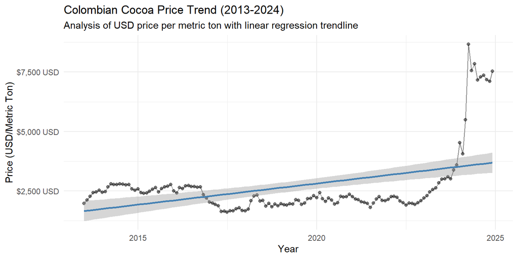

```r
# Visualizing the local cocoa price trend
ggplot(colombian_cocoa_price, aes(x = date, y = price_usd_metric_ton)) +
  geom_line(color = "gray50") +
  geom_point(alpha = 0.5) +
  geom_smooth(method = "lm", se = TRUE, color = "steelblue") +
  scale_y_continuous(labels = scales::label_dollar(suffix = " USD")) +
  labs(
    title = "Colombian Cocoa Price Trend (2013-2024)",
    subtitle = "Analysis of USD price per metric ton with linear regression trendline",
    y = "Price (USD/Metric Ton)",
    x = "Year"
  ) +
  theme_minimal()
```

##### **What does this visualization suggest?**

While the line chart shows the general direction, it can be hard to see exactly how much the prices “jump around” within a single year. To analyze this volatility more clearly, I will construct a **boxplot** to summarize price variation by year.

#### **Boxplot Analysis: How has price instability evolved over time?**

By summarizing the data into annual “snapshots,” I can see how the market’s behavior has shifted from steady predictability to high-intensity volatility.

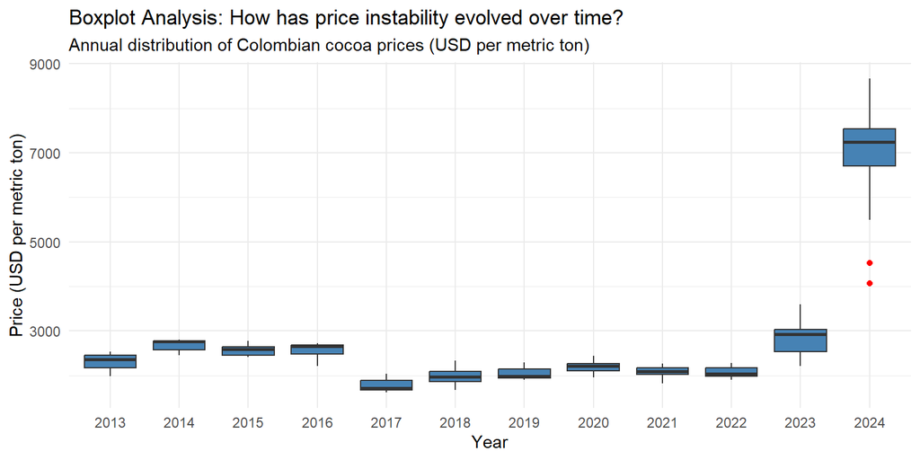

```r
# Boxplot of prices by year
ggplot(colombian_cocoa_price, aes(x = factor(year(date)), y = price_usd_metric_ton)) +
  geom_boxplot(fill = "steelblue", outlier.color = "red") +
  labs(
    title = "Boxplot Analysis: How has price instability evolved over time?",
    subtitle = "Annual distribution of Colombian cocoa prices (USD per metric ton)",
    x = "Year",
    y = "Price (USD per metric ton)"
  ) +
  theme_minimal()
```

**What does the dispersion suggest about the market?**

While the annual view shows us that prices are currently high and unstable, it doesn’t tell us **when** during the year we might find relief. To understand the seasonal dynamics and identify the most favorable months for purchasing cocoa, I will now compute the average price for each month of the year.

#### **Local Seasonality Analysis: When is the most affordable time to buy?**

To keep the analysis consistent, I focused on the period from January 2014 to December 2024. Although the dataset starts in July 2013, including only half a year could distort the results. Using full calendar years also helps align the local data with global benchmarks for later comparison.

After filtering the data, I calculated the average price for each month to identify seasonal patterns in the Colombian market.

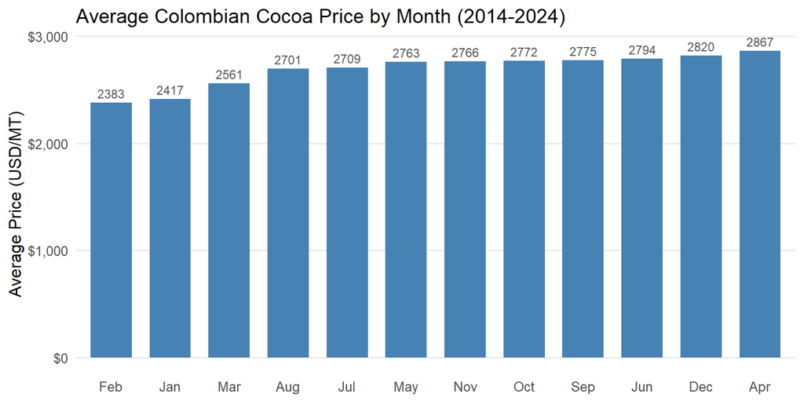

```r
# Average Colombian Cocoa Price by Month
colombian_cocoa_price %>%
  filter(date >= "2014-01-01" & date < "2025-01-01") %>%
  mutate(month = month(date, label = TRUE)) %>%
  group_by(month) %>%
  summarise(avg_price = mean(price_usd_metric_ton, na.rm = TRUE)) %>%
  arrange(avg_price) %>%
  mutate(month = fct_reorder(month, avg_price)) %>%
  ggplot(aes(x = month, y = avg_price)) +
  geom_col(fill = "steelblue", width = 0.7) +
  geom_text(aes(label = round(avg_price, 0)),
            vjust = -0.5, size = 3, color = "#555555") +
  scale_y_continuous(labels = label_dollar()) +
  theme_minimal(base_size = 12) +
  theme(
    panel.grid.major.x = element_blank(),
    panel.grid.minor = element_blank(),
    axis.text.x = element_text(angle = 0, hjust = 0.5)
  ) +
  labs(
    title = "Average Colombian Cocoa Price by Month (2014-2024)",
    x = NULL,
    y = "Average Price (USD/MT)"
  )
```

```r
# Calculating monthly average prices (2014-2024)
colombian_cocoa_price %>%
  filter(date >= "2014-01-01" & date < "2025-01-01") %>%
  mutate(month = month(date, label = TRUE)) %>%
  group_by(month) %>%
  summarise(avg_price = mean(price_usd_metric_ton, na.rm = TRUE)) %>%
  arrange(avg_price)
```

```
# A tibble: 12 × 2
   month avg_price
   <ord>     <dbl>
 1 Feb       2383.
 2 Jan       2417.
 3 Mar       2561.
 4 Aug       2701.
 5 Jul       2709.
 6 May       2763.
 7 Nov       2766.
 8 Oct       2772.
 9 Sep       2775.
10 Jun       2794.
11 Dec       2820.
12 Apr       2867.
```

The results suggest that the most cost-effective window for purchasing cocoa in Colombia tends to occur during the first quarter of the year:

- **The Early-Year Dip:** I noticed that **February (2382.6 USD/ton)**, **January (2416.7 USD/ton)**, and **March (2560.9 USD/ton)** represent the lowest averages in the selected time window.
- **Harvest Alignment:** This pattern could be interpreted as a reflection of the main harvest cycles in Colombia. It aligns with the idea that an increase in supply during these months might be putting downward pressure on prices.

#### **What does this mean for a business strategy?**

Identifying these months as the **“seasonal floor”** is a vital insight. It suggests that a company looking to maximize its margins might find it beneficial to secure its raw material contracts during this first quarter.

#### **Executive Summary: Colombia Cocoa Price**

In this phase, I analyzed how Colombian cocoa prices have evolved over the last decade. The goal was to determine if the price increases we see are part of a steady long-term trend or just temporary market “noise,” and to identify seasonal patterns that could save the business money..

##### **Key Strategic Insights**

- **A Consistent Upward Climb:** The data suggests a very clear growth trend. Over the long term, Colombian cocoa prices have been increasing by approximately **$14.83 USD per month**. While this sounds small, it confirms that the “cost of doing business” is steadily rising, likely driven by global inflation and increasing demand for quality cocoa.
- **The “Volatility Explosion” (2023–2024):** For nearly a decade (2013–2022), prices were remarkably stable and predictable. However, I noticed a dramatic shift starting in 2023. By 2024, the market entered a period of **extreme instability**. Prices didn’t just rise; they became much more “nervous,” with huge gaps between the highs and lows of the same year.
- **Timing the Market (The First Quarter Advantage):** My analysis of seasonal patterns suggests that the most affordable time to secure cocoa is during the **first quarter of the year**. Specifically, **January, February, and March** consistently show the lowest average prices.

**What This Means for Decisions:**

1. **Budgeting for Growth:** The evidence suggests a sustained upward trend, meaning long-term financial planning should incorporate progressively higher raw material costs.
2. **Strategic Sourcing:** There is a clear opportunity to maximize margins by securing contracts or increasing inventory during the **February-March window**, before prices typically begin to climb later in the year.
3. **Risk Management:** Because the market has become significantly more volatile since 2023, the “old rules” of price stability no longer apply. It suggests that the business needs more flexible pricing or hedging strategies to handle sudden jumps.

### **Global Cocoa Price**

To understand the broader context, I applied the same linear regression model to the global cocoa market. This allows me to identify long-term trends and, more importantly, see how they compare to the Colombian cocoa price behavior I analyzed earlier.

#### **Linear Regression Model: What Is the trend?**

As with the previous dataset, I used the lm() function to evaluate the relationship between **time** and the **global cocoa price per metric ton**.

```r
# Linear regression: Global price as a function of time
model_glo_cocoa <- lm(price_cocoa_usd_metric_ton ~ month_index, data = global_cocoa_price)
summary(model_glo_cocoa)
```

```
Call:
lm(formula = price_cocoa_usd_metric_ton ~ month_index, data = global_cocoa_price)

Residuals:
    Min      1Q  Median      3Q     Max
-1122.9  -517.5     2.6   282.1  6893.7

Coefficients:
            Estimate Std. Error t value Pr(>|t|)
(Intercept) 796.8134    85.6334   9.305   <2e-16 ***
month_index   6.4957     0.3538  18.361   <2e-16 ***
---
Signif. codes:  0 '***' 0.001 '**' 0.01 '*' 0.05 '.' 0.1 ' ' 1

Residual standard error: 879 on 418 degrees of freedom
Multiple R-squared:  0.4465,  Adjusted R-squared:  0.4451
F-statistic: 337.1 on 1 and 418 DF,  p-value: < 2.2e-16
```

```r
# Quantile function to compare with F-statistic
qf(0.95, df1 = 1, df2 = 418)
```

```
[1] 3.863801
```

##### **What does the global data tell us?**

- **A Significant Upward Trend:** Much like the Colombian market, the global price shows a clear and statistically significant increase. The model suggests that global prices rose, on average, by approximately **USD 6.49 per month** over the period.
- **Higher Explanatory Power:** Interestingly, the **R-squared value of 0.4465** is notably higher than what I found for the Colombian market (which was 0.18). This suggests that **time explains about 44.6% of global price movement**, indicating a slightly more “steady” long-term climb than the local Colombian price.
- **Persistent Volatility:** Despite the stronger trend, the residual standard error remains high. It could be interpreted that global prices are also heavily shaped by external “shocks” such as supply crises or changes in international demand that simple time-based models cannot fully capture.

#### **Linear Trend Plot - Global Cocoa Price Trend (1990-2024)**

By visualizing the global price alongside its regression line, I can see how the world market has behaved over the last several decades. This provides a high-level view of the “tide” that carries the Colombian market along with it.

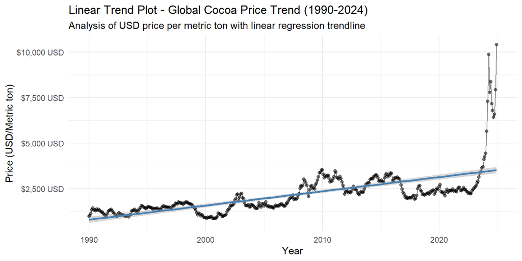

```r
# Visualizing the global cocoa price trend
ggplot(data = global_cocoa_price, aes(x = observation_date, y = price_cocoa_usd_metric_ton)) +
  geom_line(color = "gray50") +
  geom_point(alpha = 0.5) +
  geom_smooth(method = "lm", se = TRUE, color = "steelblue") +
  scale_y_continuous(labels = scales::label_dollar(suffix = " USD")) +
  labs(
    title = "Linear Trend Plot - Global Cocoa Price Trend (1990-2024)",
    subtitle = "Analysis of USD price per metric ton with linear regression trendline",
    y = "Price (USD/Metric ton)",
    x = "Year"
  ) +
  theme_minimal()
```

##### **What does this mean for a business strategy?**

Seeing the global market behave so aggressively in recent years helps us refine our strategy.

- **Macro over Micro:** Since the local trend follows the global one so closely, a business must keep its eyes on global news just as much as local Colombian news.
- **Preparing for Volatility:** The “oscillations” of the past were more predictable, but the recent spikes suggest that “safe” price ranges from five years ago may no longer apply.

#### **Boxplot Analysis: How has global price instability evolved?**

By dividing the global data into annual snapshots, I can identify when the market moved away from its historical cycles into the current phase of heightened volatility and compare this shift with the patterns previously observed in the Colombian cocoa market.

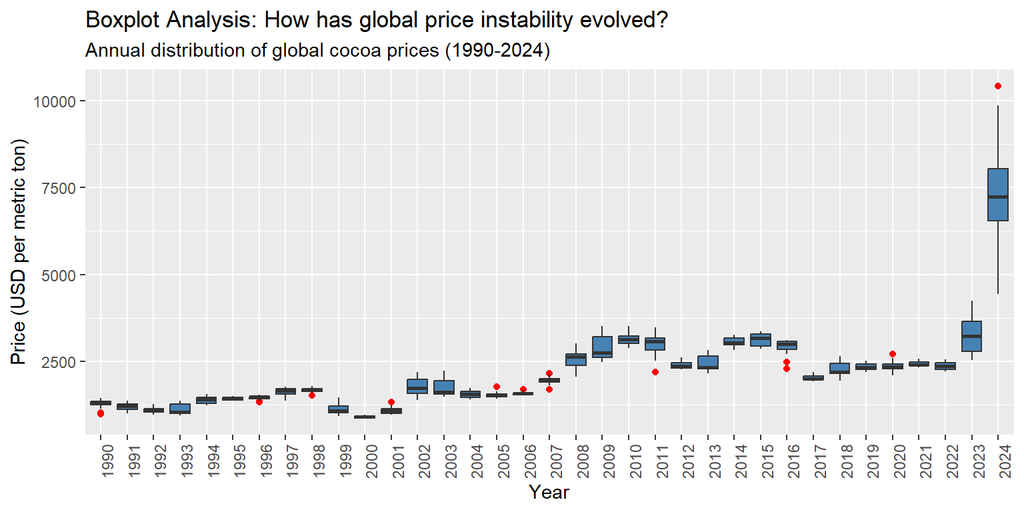

```r
# Global Price Distribution by Year
ggplot(global_cocoa_price, aes(x = factor(year(observation_date)), y = price_cocoa_usd_metric_ton)) +
  geom_boxplot(fill = "steelblue", outlier.color = "red") +
  labs(
    title = "Boxplot Analysis: How has global price instability evolved?",
    subtitle = "Annual distribution of global cocoa prices (1990-2024)",
    x = "Year",
    y = "Price (USD per metric ton)"
  ) +
  theme(axis.text.x = element_text(angle = 90, hjust = 1))
```

##### **What does this suggest about the current market?**

- **Decades of Relative Calm (1990–2022):** Global prices occupied a stable band for over 30 years. While there were multi-year fluctuations, the “boxes” remained compact, indicating predictable monthly movement.
- **The 2023–2024 Surge:** The market shows a dramatic structural shift starting in 2023. By 2024, the median price reaches unprecedented levels, and the vertical expansion of the boxes indicates that variability has increased sharply.
- **Mirroring the Local Market:** This behavior **closely mirrors** the surge I saw in the Colombian dataset. It may be interpreted that Colombia’s recent price hike was not caused by local factors, but was likely a direct result of these global supply-chain shocks.

##### **What does this mean for a business strategy?**

- **Global Driver Identification:** The statistical evidence indicates that Colombian prices closely follow global price movements. For exporters, this implies that monitoring local harvest volumes alone is insufficient to anticipate cost dynamics.
- **A New Baseline:** The 2024 outliers suggest that we have entered a “new normal.” It aligns with the idea that historical price floors may no longer be relevant for long-term budgeting.

#### **Global Seasonality Analysis: Identifying Market Alignment**

To maintain a balanced comparison with the Colombian Cacao Price data, I filtered the global dataset to the 2014–2024 period. This identifies whether the “buy low” window is a local phenomenon or part of a worldwide trend.

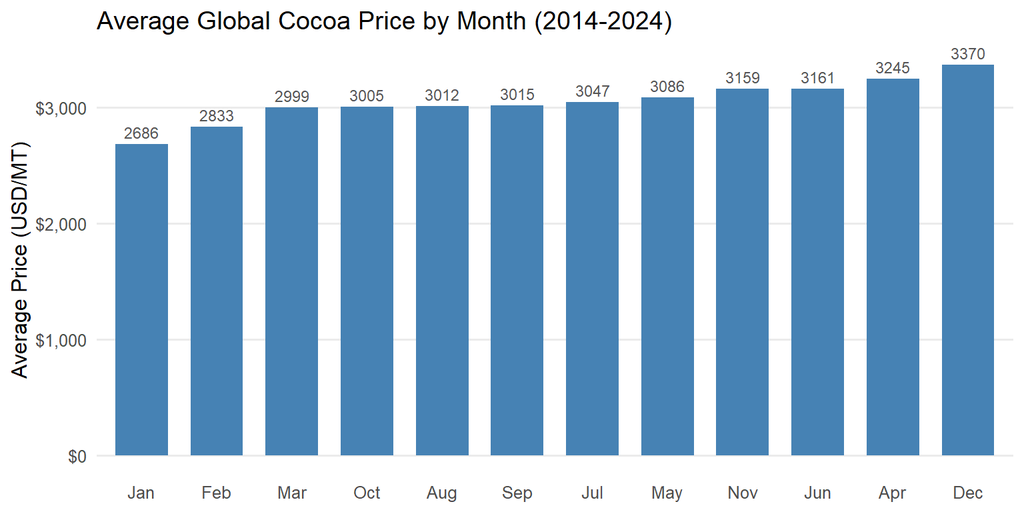

```r
# Average Global Cocoa Price by Month
global_cocoa_price %>%
  filter(observation_date >= "2014-01-01" & observation_date < "2025-01-01") %>%
  mutate(month = month(observation_date, label = TRUE)) %>%
  group_by(month) %>%
  summarise(avg_price = mean(price_cocoa_usd_metric_ton, na.rm = TRUE)) %>%
  arrange(avg_price) %>%
  mutate(month = fct_reorder(month, avg_price)) %>%
  ggplot(aes(x = month, y = avg_price)) +
  geom_col(fill = "#4682B4", width = 0.7) +
  geom_text(aes(label = round(avg_price, 0)),
            vjust = -0.5, size = 3, color = "#555555") +
  scale_y_continuous(labels = label_dollar()) +
  theme_minimal(base_size = 12) +
  theme(
    panel.grid.major.x = element_blank(),
    panel.grid.minor = element_blank(),
    axis.text.x = element_text(angle = 0, hjust = 0.5)
  ) +
  labs(
    title = "Average Global Cocoa Price by Month (2014-2024)",
    x = NULL,
    y = "Average Price (USD/MT)"
  )
```

```r
# Global Monthly Averages (2014-2024)
global_cocoa_price %>%
  filter(observation_date >= "2014-01-01" & observation_date < "2025-01-01") %>%
  mutate(month = month(observation_date, label = TRUE)) %>%
  group_by(month) %>%
  summarise(avg_price = mean(price_cocoa_usd_metric_ton, na.rm = TRUE)) %>%
  arrange(avg_price)
```

```
# A tibble: 12 × 2
   month avg_price
   <ord>     <dbl>
 1 Jan       2686.
 2 Feb       2833.
 3 Mar       2999.
 4 Oct       3005.
 5 Aug       3012.
 6 Sep       3015.
 7 Jul       3047.
 8 May       3086.
 9 Nov       3159.
10 Jun       3161.
11 Apr       3245.
12 Dec       3370.
```

##### **What does the global seasonality suggest?**

- **Shared “First Quarter” Lows:** I noticed that **January (2685.7 USD)**, **February (2832.8 USD)**, and **March (2999.3 USD)** represent the global price floors. This broadly aligns with the Colombian market, where the same months were also the most affordable.
- **Price Disparity:** It could be interpreted that the Colombian Cocoa price sits lower than the global average during these months. For instance, in February, the Colombian average **(2383 USD)** is significantly lower than the global **(2832 USD)**.
- **Independent Local Dynamics:** Although the seasonal windows align, the monthly rankings differ (global lows begin in January, while Colombian lows occur in February). This indicates that while global forces set the overall seasonal trend, local factors such as harvest timing and logistics still influence the precise monthly price behavior in Colombia.

##### **What does this mean for a business strategy?**

- **A Unified Procurement Window:** The evidence suggests that the first quarter consistently reflects lower prices at the global level, supporting a procurement strategy focused on January through March.
- **Colombian Advantage:** Colombian Advantage: During this same period, Colombian prices appear to sit below the global benchmark. This indicates a potential double advantage: seasonal lows combined with a comparatively competitive local price.

#### **Executive Summary: Global Cocoa Price**

This section shifts the focus to the global stage to determine how much of the Colombian price behavior is driven by worldwide forces. The findings confirm that the local market is a “passenger” on a much larger global ship.

##### **Key Strategic Insights**

- **Global-Local Synchronization:** The evidence suggests that Colombian cocoa prices closely follow global trends. Although the global price shows a steadier upward movement **(explaining 44% of its own variation)**, both markets share the same long-term trajectory, indicating that global shocks strongly influence local price dynamics.
- **The “New Normal” of Volatility:** Similar to the Colombian data, global prices followed relatively stable historical cycles between 1990 and 2022 before showing a structural shift in **2023–2024**. This recent surge suggests a departure from past patterns toward a period of heightened and unusually strong price volatility.
- **A Unified Global “Buying Window”:** The global seasonal price floor aligns with the Colombian pattern. **January, February, and March** consistently show the lowest average prices, identifying a clear window for strategic procurement.
- **The Colombian Price Advantage:** While the timing is the same, Colombian prices consistently sit **lower than the global average** during this first-quarter dip.

**What This Means for Decisions:**

Business planning must prioritize global market intelligence over local data alone. The most effective cost-saving strategy is to concentrate sourcing in **Colombia during the first quarter**, where local prices are at their most competitive relative to the global market.

### **Global Chocolate Price**

#### **Linear Trend Plot: How do manufacturer prices behave over time?**

I applied a linear regression to the **Chocolate Producer Price Index (PPI)** to see if the industrial side of the market follows the same volatility as the raw cocoa market.

```r
# Linear regression: Chocolate PPI as a function of time
model_glo_chocolate <- lm(producer_price_index ~ month_index, data = chocolate_producer_price)
summary(model_glo_chocolate)
```

```
Call:
lm(formula = producer_price_index ~ month_index, data = chocolate_producer_price)

Residuals:
    Min      1Q  Median      3Q     Max
-11.162  -6.118   1.022   4.585  13.871

Coefficients:
            Estimate Std. Error t value Pr(>|t|)
(Intercept) 93.50775    0.97163   96.24   <2e-16 ***
month_index  0.22550    0.01077   20.94   <2e-16 ***
---
Signif. codes:  0 '***' 0.001 '**' 0.01 '*' 0.05 '.' 0.1 ' ' 1

Residual standard error: 6.116 on 155 degrees of freedom
Multiple R-squared:  0.7388,  Adjusted R-squared:  0.7371
F-statistic: 438.3 on 1 and 155 DF,  p-value: < 2.2e-16
```

```r
# Quantile function to compare with F-statistic
qf(0.95, df1 = 1, df2 = 161)
```

```
[1] 3.899867
```

##### **What does the industrial data suggest?**

- **A Highly Predictable Trend:** The **R-squared values** $(R^2 = 0.738)$ is the highest we have seen so far. It suggests that time explains nearly **74% of the variation** in chocolate producer prices. Unlike raw cocoa, which is prone to sudden shocks, the industrial index moves in a much more linear and stable upward path.
- **Strong Statistical Support:** An **F-statistic of 438.3** (far exceeding the critical value of 3.90) and a $(p = 2e-16)$ provide strong evidence of a consistent monthly increase of approximately **0.22 units**.
- **Low Residual Noise:** The low **residual standard error $(s = 6.11)$** could be interpreted as a sign of price “stickiness.” It aligns with the idea that manufacturers don’t change their prices as rapidly as the raw commodity market fluctuates.

##### **What does this mean for a business strategy?**

The contrast between the “stable” chocolate PPI and the “volatile” cocoa price is a key business insight.

#### **Trend Line Plot: Industrial vs. Raw Material behavior**

By visualizing the **Chocolate Producer Price Index (PPI)**, I can see how the industrial side of the market has responded to the volatility we’ve seen in raw cocoa.

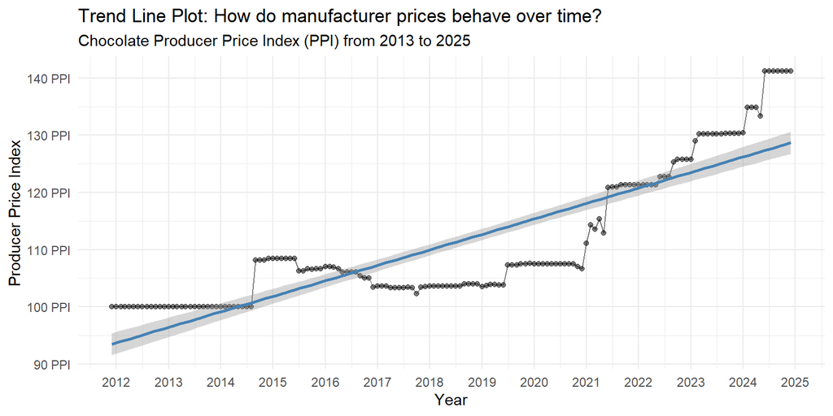

```r
# Visualizing the Chocolate Producer Price Index (PPI) Trend
ggplot(data = chocolate_producer_price, aes(x = observation_date, y = producer_price_index)) +
  geom_line(color = "gray50") +
  geom_point(alpha = 0.5) +
  geom_smooth(method = "lm", se = TRUE, color = "steelblue") +
  scale_y_continuous(labels = scales::label_number(suffix = " PPI")) +
  labs(
    title = "Trend Line Plot: How do manufacturer prices behave over time?",
    subtitle = "Chocolate Producer Price Index (PPI) from 2013 to 2025",
    y = "Producer Price Index",
    x = "Year"
  ) +
  theme_minimal() +
  scale_x_date(date_breaks = "1 years", date_labels = "%Y")
```

##### **What does this mean for a business strategy?**

The trend here is much more “linear” than raw cocoa $(R^2 ≈ 0.74)$, which suggests that once manufacturer prices go up, they stay up.

#### **Linear Trend and Variability: Is the industrial trend accelerating?**

The boxplot visualization allows me to look beyond simple averages and understand how the stability of the industrial market has changed over time.

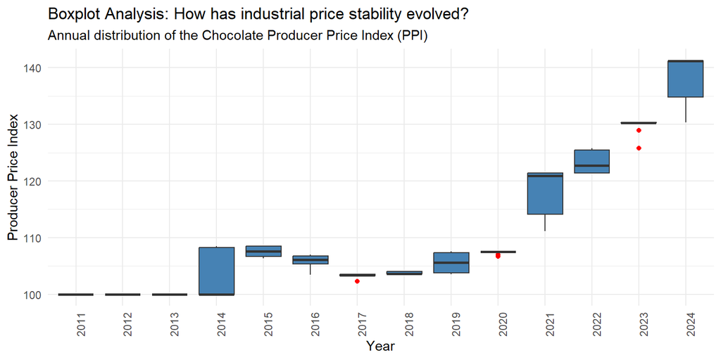

```r
# Annual Distribution of the Chocolate Producer Price Index
ggplot(chocolate_producer_price, aes(x = factor(year(observation_date)), y = producer_price_index)) +
  geom_boxplot(fill = "steelblue", outlier.color = "red") +
  labs(
    title = "Boxplot Analysis: How has industrial price stability evolved?",
    subtitle = "Annual distribution of the Chocolate Producer Price Index (PPI)",
    x = "Year",
    y = "Producer Price Index"
  ) +
  theme_minimal() +
  theme(axis.text.x = element_text(angle = 90, hjust = 1))
```

#### **Industrial Seasonality: Are Manufacturer Prices Seasonal?**

To complete our seasonality comparison, I analyzed the monthly averages of the Chocolate Producer Price Index (PPI) between 2014 and 2024. This allows me to see if the “cheap months” for raw cocoa result in lower prices for finished chocolate products.

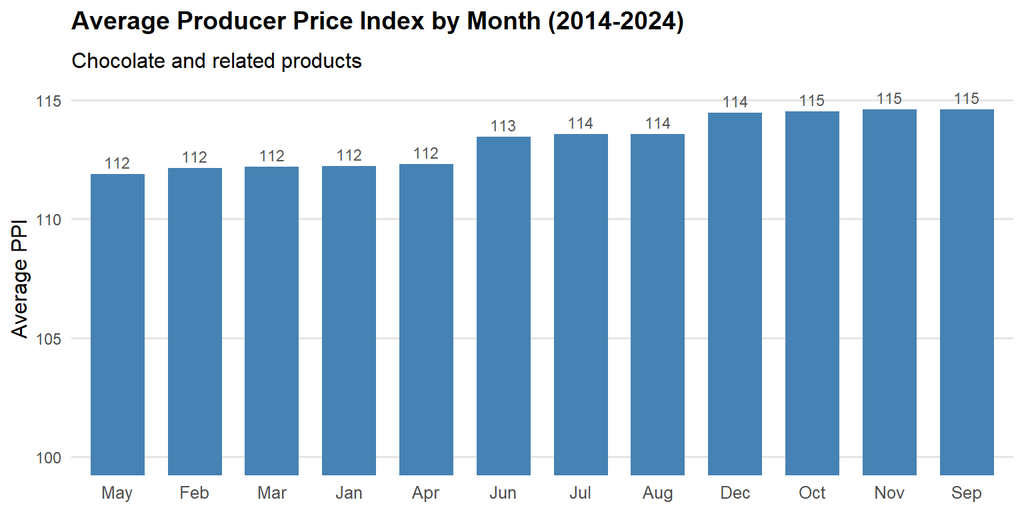

```r
# Calculating monthly average Producer Price Index (2014-2024)
chocolate_producer_price %>%
  filter(observation_date > "2014-01-01" & observation_date < "2025-01-01") %>%
  mutate(month = month(observation_date, label = TRUE)) %>%
  group_by(month) %>%
  summarise(avg_price = mean(producer_price_index, na.rm = TRUE)) %>%
  arrange(avg_price) %>%
  mutate(month = fct_inorder(month)) %>%
  ggplot(aes(x = month, y = avg_price)) +
  geom_col(fill = "steelblue", width = 0.7) +
  geom_text(aes(label = round(avg_price, 0)),
            vjust = -0.5, size = 3, color = "#555555") +
  coord_cartesian(ylim = c(100, 115)) +
  theme_minimal(base_size = 12) +
  theme(
    panel.grid.major.x = element_blank(),
    panel.grid.minor = element_blank(),
    panel.grid.major.y = element_line(color = "#E5E5E5"),
    plot.title = element_text(size = 14, face = "bold", margin = margin(b = 10)),
    axis.text.y = element_text(size = 9)
  ) +
  labs(
    title = "Average Producer Price Index by Month (2014-2024)",
    subtitle = "Chocolate and related products",
    x = NULL,
    y = "Average PPI"
  )
```

```r
# Calculating monthly average Producer Price Index (2014-2024)
chocolate_producer_price %>%
  filter(observation_date > "2014-01-01" & observation_date < "2025-01-01") %>%
  mutate(month = month(observation_date, label = TRUE)) %>%
  group_by(month) %>%
  summarise(avg_price = mean(producer_price_index, na.rm = TRUE)) %>%
  arrange(avg_price)
```

```
# A tibble: 12 × 2
   month avg_price
   <ord>     <dbl>
 1 May        112.
 2 Feb        112.
 3 Mar        112.
 4 Jan        112.
 5 Apr        112.
 6 Jun        113.
 7 Jul        114.
 8 Aug        114.
 9 Dec        114.
10 Oct        115.
11 Nov        115.
12 Sep        115.
```

##### **What does this mean for a business strategy?**

- **Predictable Industrial Costs:** For a wholesaler or retailer, this suggests that the timing of a purchase order for finished chocolate matters much less than the timing for raw cocoa.
- **Input vs. Output:** While I found that February is a great time to buy raw cocoa beans, that discount doesn’t seem to “trickle down” to the PPI in the same month. It aligns with the idea that manufacturer pricing is driven more by long-term inflation and global trends than by the harvest month.

#### **Executive Summary: Producer Price Index (PPI)**

In this section, I analyzed the **Producer Price Index (PPI)** to understand how the industrial side of the marketthe people who turn beans into chocolate behaves. The results suggest a market that was historically very stable but has recently reached a breaking point.

##### **Key Strategic Insights**

- **The End of “Price Stickiness”:** Between 2013 and 2022, manufacturer prices remained relatively stable $(R^2 = 0.74)$, following a gradual and predictable upward path. However, beginning in 2023, the data suggests a potential regime shift. Manufacturers appear to have reduced their capacity to absorb rising input costs, with raw cocoa price spikes increasingly reflected in the industrial price index.
- **Predictability vs. Volatility:** Unlike raw cocoa prices, which are subject to sharp fluctuations, industrial prices tend to be more rigid. Once they increase, they rarely adjust downward. This suggests that even if raw cocoa prices moderate in the future, finished chocolate prices may remain elevated for an extended period.
- **Zero Seasonal Advantage:** While raw cocoa has a clear “buy low” window in the first quarter, the industrial index shows **no significant seasonality**. The difference between the cheapest and most expensive months is less than **3%**.

**Strategic Takeaway:** Waiting for seasonal price drops is ineffective when selling finished chocolate products, as the PPI shows no meaningful seasonality. Instead, businesses should plan around persistently high industrial prices, even if raw cocoa costs temporarily decline, and adjust long-term pricing and margin protection strategies accordingly.

### **Colombian Chocolate Exports**

#### **Export Analysis: Are Colombian Chocolates Gaining Global Ground?**

To understand the global appetite for Colombian finished products, I processed the export data for two key categories from Comtrade Plus:

- **HS 180631:** Chocolate in blocks, slabs, or bars (filled).
- **HS 180632:** Chocolate in blocks, slabs, or bars (not filled).

#### **Visualizing Export Trends (2016–2024)**

I generated two separate time-series plots to see if there is a clear “upward climb” in the value of these exports.

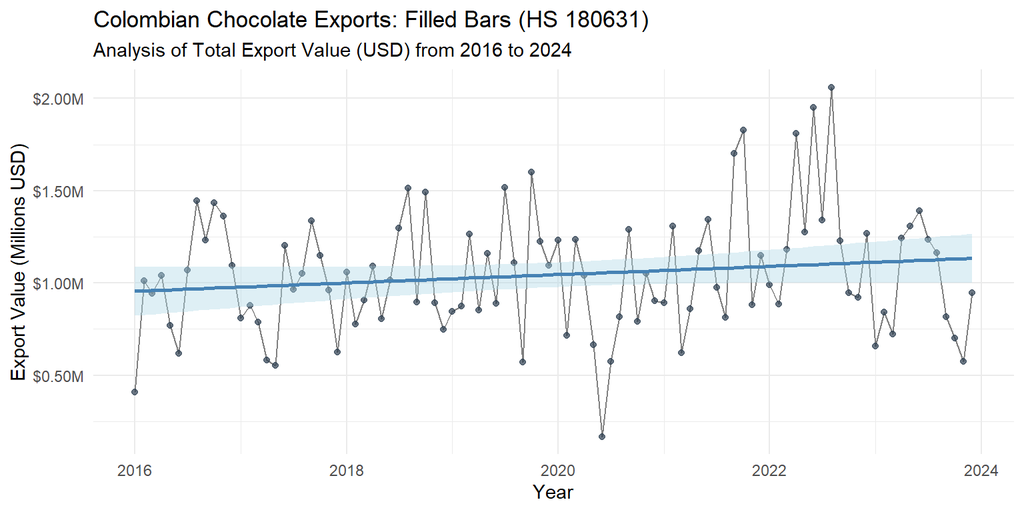

```r
# Visualizing 'Filled' Chocolate Exports (HS 180631)
ggplot(data = chocolate_exports_180631, aes(x = ref_period_id, y = primary_value)) +
  geom_line(color = "gray50") +
  geom_point(alpha = 0.7, color = "#2C3E50") +
  geom_smooth(method = "lm", se = TRUE, color = "steelblue", fill = "lightblue") +
  scale_y_continuous(labels = scales::label_dollar(scale = 1e-6, suffix = "M")) +
  labs(
    title = "Colombian Chocolate Exports: Filled Bars (HS 180631)",
    subtitle = "Analysis of Total Export Value (USD) from 2016 to 2024",
    y = "Export Value (Millions USD)",
    x = "Year"
  ) +
  theme_minimal()
```

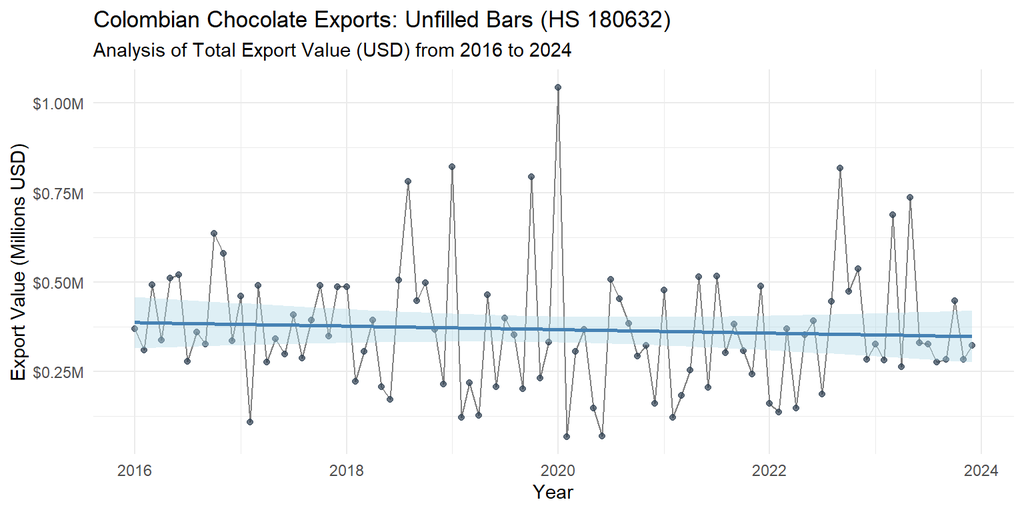

```r
# Visualizing 'Not Filled' Chocolate Exports (HS 180632)
ggplot(data = chocolate_exports_180632, aes(x = ref_period_id, y = primary_value)) +
  geom_line(color = "gray50") +
  geom_point(alpha = 0.7, color = "#2C3E50") +
  geom_smooth(method = "lm", se = TRUE, color = "steelblue", fill = "lightblue") +
  scale_y_continuous(labels = scales::label_dollar(scale = 1e-6, suffix = "M")) +
  labs(
    title = "Colombian Chocolate Exports: Unfilled Bars (HS 180632)",
    subtitle = "Analysis of Total Export Value (USD) from 2016 to 2024",
    y = "Export Value (Millions USD)",
    x = "Year"
  ) +
  theme_minimal()
```

##### **What does the export data suggest?**

- **High Transactional Dispersion:** I noticed that the points are highly scattered. It indicates that the value of shipments varies significantly from one period to the next, likely due to the irregularities of international trade contracts.
- **Flat Long-Term Growth:** The regression models (blue lines) stay relatively horizontal. While filled chocolates (180631) show a slight upward tilt and unfilled ones (180632) a slight dip, the statistical evidence does not suggest a dramatic structural increase in export value over this eight-year window.
- **Resilience vs. Growth:** It aligns with the idea that while the Colombian chocolate market is active and maintaining its global presence, it has not yet transitioned into a high-growth phase in terms of total dollar value per transaction.

##### **What does this mean for a business strategy?**

- **Market Opportunity:** The “flatness” of the export trend suggests a unique opportunity: Colombian exports appear relatively uninfluenced by global cocoa price trends. This indicates a level of stability, as export volumes have remained constant regardless of external market volatility.
- **Stability in Uncertainty:** Despite the massive price spikes in raw cocoa we saw in 2023–2024, the export values have remained relatively stable. This could be interpreted as a sign that Colombian exporters are maintaining their international commitments even under high-cost pressure.

To better understand these dynamics, I will now proceed with a linear regression model to evaluate the relationship between time (*month_index*) and export value (*primary_value*) in both datasets.

#### **Linear Regression Analysis: Are Exports Growing Over Time?**

To evaluate the long-term growth of Colombian chocolate exports, I applied a linear regression model to the transactional value (USD) over time.

```r
# Regression for Filled Chocolates (HS 180631)
model_exp_180631 <- lm(primary_value ~ month_index, data = chocolate_exports_180631)
summary(model_exp_180631)
```

```
Call:
lm(formula = primary_value ~ month_index, data = chocolate_exports_180631)

Residuals:
    Min      1Q  Median      3Q     Max
-889743 -205750  -11130  185091  957069

Coefficients:
            Estimate Std. Error t value Pr(>|t|)
(Intercept)   955620      67080  14.246   <2e-16 ***
month_index     1877       1220   1.539    0.127
---
Signif. codes:  0 '***' 0.001 '**' 0.01 '*' 0.05 '.' 0.1 ' ' 1

Residual standard error: 331200 on 94 degrees of freedom
Multiple R-squared:  0.02457, Adjusted R-squared:  0.01419
F-statistic: 2.368 on 1 and 94 DF,  p-value: 0.1272
```

```r
# Regression for Unfilled Chocolates (HS 180632)
model_exp_180632 <- lm(primary_value ~ month_index, data = chocolate_exports_180632)
summary(model_exp_180632)
```

```
Call:
lm(formula = primary_value ~ month_index, data = chocolate_exports_180632)

Residuals:
    Min      1Q  Median      3Q     Max
-299496 -106221  -26035  105843  676129

Coefficients:
            Estimate Std. Error t value Pr(>|t|)
(Intercept) 387284.6    36119.7  10.722   <2e-16 ***
month_index   -408.0      656.8  -0.621    0.536
---
Signif. codes:  0 '***' 0.001 '**' 0.01 '*' 0.05 '.' 0.1 ' ' 1

Residual standard error: 178300 on 94 degrees of freedom
Multiple R-squared:  0.004088,    Adjusted R-squared:  -0.006507
F-statistic: 0.3858 on 1 and 94 DF,  p-value: 0.536
```

##### **What does this mean for a business strategy?**

- **Non-Linear Dynamics:** It could be interpreted that the Colombian export market does not grow in a “straight line.” Instead, it aligns with a market driven by discrete events such as large individual contracts, seasonal peaks, or external global shocks rather than steady monthly growth.
- **Structural Stability:** Despite the lack of growth, the lack of a significant “downward” trend during a period of global crisis (2020–2024) suggests a resilient base of international buyers for Colombian chocolate.

##### **Executive Summary: Colombian Chocolate Exports**

In this section, I analyzed the international demand for Colombian finished chocolate (HS 180631 and HS 180632). The findings suggest a market that is resilient and stable but currently lacks a high-growth trajectory.

##### **Key Strategic Insights**

**Strategic Takeaway:** The “flatness” of the export market suggests a major opportunity for growth through value-added strategies. Since the current market is stable but not expanding, leveraging Colombia’s “Premium” status could be the key to shifting these trends upward.

## **Merging data**

Now I will take a deeper look at our datasets by merging the some of the used earlier. This step will allow me to uncover additional insights that can help me address the business task.

### **Consolidating Colombian Chocolate Exports**

I began by combining the two specific chocolate export categories (filled and unfilled bars) into a single, unified dataset. This allows me to analyze overall trends and seasonality more effectively.

```r
# Merging export categories into a single dataframe
merged_chocolate_exports <- bind_rows(
  chocolate_exports_180631,
  chocolate_exports_180632
) %>%
  group_by(ref_period_id, month_index) %>%
  summarise(
    primary_value = sum(primary_value, na.rm = TRUE),
    net_wgt = sum(net_wgt, na.rm = TRUE),
    .groups = "drop"
  )
```

### **Synchronizing Global and Local Cocoa Prices**

To ensure a fair comparison, I restricted the timeline to June 2025. This prevents temporal misalignment, as the global and local datasets have different start dates. This merge is essential to identify whether the Colombian market moves independently or as a passenger of global trends.

```r
# Aligning local prices with the global prices
merged_cocoa_price <-
  merge(
    x = colombian_cocoa_price, y = global_cocoa_price,
    by.x = "date",
    by.y = "observation_date",
    all.x = TRUE
  ) %>%
  filter(date < "2025-06-01") %>%
  select(
    date, trm_usd,
    price_usd_metric_ton,
    price_cocoa_usd_metric_ton
  ) %>%
  rename(
    colombian_price_usd_metric_ton = price_usd_metric_ton,
    global_price_usd_metric_ton = price_cocoa_usd_metric_ton
  )
```

### **Evaluating the Influence of Global Prices on Exports**

I will now merge the `merged_chocolate_exports` dataset with `global_cocoa_price` to examine whether peak export months coincide with favorable or unfavorable global cocoa price levels.

This analysis allows me to explore a key business question: **Does global price volatility influence the timing of Colombia’s chocolate exports?** It also helps determine whether high-demand months coincide with favorable price windows.

```r
# Merging exports with global cocoa prices
merged_exports_and_cocoa <-
  merge(
    x = merged_chocolate_exports, y = global_cocoa_price,
    by.x = "ref_period_id",
    by.y = "observation_date",
    all.x = TRUE
  )
```

### **The Cost-to-Producer Connection (Cocoa vs. PPI)**

I combined global cocoa prices with the Producer Price Index (PPI) to assess how changes in raw material costs are transmitted to production prices. While the industry may adjust gradually under normal conditions, this merge allows me to evaluate whether major shocks lead to immediate pass-through effects or delayed price adjustments.

```r
# Analyzing the relationship between raw inputs and industrial output
merged_cocoa_and_ppi <- merge(
  x = global_cocoa_price,
  y = chocolate_producer_price,
  by = "observation_date",
  all.x = TRUE
) %>%
  dplyr::filter(!is.na(producer_price_index)) %>%
  rename(
    global_price_usd_metric_ton = price_cocoa_usd_metric_ton
  )
```

### **Building the Economic Export Data**

Finally, I created the `merged_economic_exports` dataset, which combines export performance with the exchange rate (TRM) and cocoa prices. This integrated dataset allows me to examine how external economic variables relate to actual trade dynamics.

```r
# Final merge to observe exports, exchange rates, and prices together
merged_economic_exports <-
  merge(
    x = merged_chocolate_exports, y = merged_cocoa_price,
    by.x = "ref_period_id",
    by.y = "date",
    all.x = TRUE
  )
```

## **Data Cleaning [Revisited]**

Before continuing with our analysis, I will clean the R environment and free up RAM by removing dataframes that are no longer needed.

```r
# List all objects in the current R workspace to verify state
ls()
```

```
 [1] "avg_price_kg"                   "chocolate_exports_180631"
 [3] "chocolate_exports_180632"       "chocolate_producer_price"
 [5] "colombian_cocoa_price"          "encoding"
 [7] "global_cocoa_price"             "i"
 [9] "input_file"                     "merged_chocolate_exports"
[11] "merged_cocoa_and_ppi"           "merged_cocoa_price"
[13] "merged_economic_exports"        "merged_exports_and_cocoa"
[15] "model_col_cocoa"                "model_exp_180631"
[17] "model_exp_180632"               "model_glo_chocolate"
[19] "model_glo_cocoa"                "out_dir"
[21] "raw_chocolate_exports_180631"   "raw_chocolate_exports_180632"
[23] "raw_chocolate_exports_comtrade" "raw_chocolate_producer_price"
[25] "raw_colombian_cocoa_price"      "raw_global_cocoa_price"
[27] "sizes"                          "sizes_datasets"
[29] "sql_chocolate_exports_comtrade" "sql_chocolate_producer_price"
[31] "sql_colombian_cocoa_price"      "sql_con"
[33] "sql_global_cocoa_price"
```

```r
# Remove original raw datasets to free up RAM and reduce clutter
rm(
  raw_colombian_cocoa_price,
  raw_global_cocoa_price,
  raw_chocolate_exports_comtrade,
  raw_chocolate_producer_price,
  raw_chocolate_exports_180631,
  raw_chocolate_exports_180632
)

# Confirm removal
ls()
```

```
 [1] "avg_price_kg"                   "chocolate_exports_180631"
 [3] "chocolate_exports_180632"       "chocolate_producer_price"
 [5] "colombian_cocoa_price"          "encoding"
 [7] "global_cocoa_price"             "i"
 [9] "input_file"                     "merged_chocolate_exports"
[11] "merged_cocoa_and_ppi"           "merged_cocoa_price"
[13] "merged_economic_exports"        "merged_exports_and_cocoa"
[15] "model_col_cocoa"                "model_exp_180631"
[17] "model_exp_180632"               "model_glo_chocolate"
[19] "model_glo_cocoa"                "out_dir"
[21] "sizes"                          "sizes_datasets"
[23] "sql_chocolate_exports_comtrade" "sql_chocolate_producer_price"
[25] "sql_colombian_cocoa_price"      "sql_con"
[27] "sql_global_cocoa_price"
```

### **What does this step achieve for the project?**

- **Operational Efficiency:** Cleaning the environment at this stage prevents accidental references to uncleaned data. It aligns with the best practice of keeping the workspace “production-ready.”
- **Performance:** Freeing up RAM is particularly useful as I prepare to run more complex correlations and potentially multivariate models that require more system resources.

## **Summary Statistics [Revisited]**

Before diving deeper into the correlation phase, I am taking a first glance at the merged datasets. This step ensures that the structure is aligned for the complex analysis ahead and provides preliminary insights into the relationships between our key variables.

### **Comparing Global and Local Cocoa Prices**

By aligning these two datasets, I can now confirm a structural price gap that was not as evident when analyzing them separately.

```r
# Summary of the merged price relationship
merged_cocoa_price %>%
  select(date, colombian_price_usd_metric_ton, global_price_usd_metric_ton) %>%
  summary()
```

```
      date            colombian_price_usd_metric_ton global_price_usd_metric_ton
 Min.   :2013-07-01   Min.   :1616                   Min.   : 1918
 1st Qu.:2016-05-08   1st Qu.:2006                   1st Qu.: 2316
 Median :2019-03-16   Median :2269                   Median : 2530
 Mean   :2019-03-17   Mean   :2677                   Mean   : 3033
 3rd Qu.:2022-01-24   3rd Qu.:2666                   3rd Qu.: 3077
 Max.   :2024-12-01   Max.   :8672                   Max.   :10412
```

**What does this suggest?**

The merged data reveals that Colombian prices are consistently lower than the global benchmark. I noticed the **Colombian median (2,269)** is roughly 10 % below the **Global median (2,530)**, suggesting that Colombia maintains a competitive cost advantage in the raw material market.

### **Export Value vs. Global Price Volatility**

I examined the relationship between total export value and global pricing to see if international buyers pulled back during price hikes.

```r
# Summary of Exports and Global Cocoa Prices
merged_exports_and_cocoa %>%
  select(ref_period_id, primary_value, price_cocoa_usd_metric_ton) %>%
  summary()
```

```
 ref_period_id        primary_value     price_cocoa_usd_metric_ton
 Min.   :2016-01-01   Min.   : 235245   Min.   :1918
 1st Qu.:2017-12-24   1st Qu.:1115414   1st Qu.:2237
 Median :2019-12-16   Median :1408679   Median :2388
 Mean   :2019-12-16   Mean   :1412678   Mean   :2497
 3rd Qu.:2021-12-08   3rd Qu.:1623965   3rd Qu.:2591
 Max.   :2023-12-01   Max.   :2505933   Max.   :4254
```

### **Industrial Response: PPI vs. Raw Material Costs**

This comparison allows me to assess whether manufacturers’ output prices (PPI) adjust in line with volatile input costs (global cocoa prices).

```r
# Summary of PPI and Global Cocoa Price
merged_cocoa_and_ppi %>%
  select(observation_date, producer_price_index, global_price_usd_metric_ton) %>%
  summary()
```

```
 observation_date     producer_price_index global_price_usd_metric_ton
 Min.   :2011-12-01   Min.   :100.0        Min.   : 1918
 1st Qu.:2015-03-01   1st Qu.:103.4        1st Qu.: 2295
 Median :2018-06-01   Median :106.7        Median : 2467
 Mean   :2018-06-01   Mean   :111.1        Mean   : 2949
 3rd Qu.:2021-09-01   3rd Qu.:121.4        3rd Qu.: 3032
 Max.   :2024-12-01   Max.   :141.2        Max.   :10412
```

**What does this suggest?**

While both the Producer Price Index and Global Cocoa Price are trending upward, I observed that cocoa prices are growing at a much faster rate than the PPI. It may be interpreted that the industry is absorbing part of the raw material cost increases rather than passing them entirely through to the final product.

### **The Economic Framework - Exports, TRM and Prices**

Finally, I reviewed the master economic data to see how the exchange rate (TRM) interacts with our other variables.

```r
# Summary of Economic Drivers and Exports
merged_economic_exports %>%
  select(ref_period_id, primary_value, trm_usd, global_price_usd_metric_ton) %>%
  summary()
```

```
 ref_period_id        primary_value        trm_usd     global_price_usd_metric_ton
 Min.   :2016-01-01   Min.   : 235245   Min.   :2766   Min.   :1918
 1st Qu.:2017-12-24   1st Qu.:1115414   1st Qu.:2997   1st Qu.:2237
 Median :2019-12-16   Median :1408679   Median :3411   Median :2388
 Mean   :2019-12-16   Mean   :1412678   Mean   :3532   Mean   :2497
 3rd Qu.:2021-12-08   3rd Qu.:1623965   3rd Qu.:3910   3rd Qu.:2591
 Max.   :2023-12-01   Max.   :2505933   Max.   :4927   Max.   :4254
```

The summary statistics suggest a consistent export performance, with a median value of **$1.41M**, despite a TRM that moved significantly between **$2,766** and **$4,927**. While global prices averaged **$2,497** per metric ton, they reached a peak of **$4,254**, yet the data aligns with the possibility that Colombian exports remain resilient to these external shifts.

## **Merge explorations**

### **Colombian Chocolate Exports**

#### **Seasonality in Colombian Chocolate Exports**

To identify recurring demand cycles, I calculated the average export value by month. This provides a baseline before applying the more complex STL decomposition.

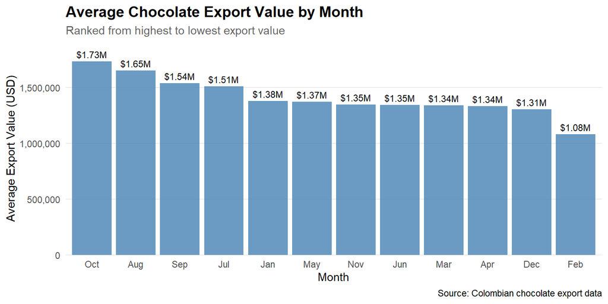

```r
# Identifying months with highest average export values
monthly_exports <- merged_chocolate_exports %>%
  mutate(ref_month = month(ref_period_id, label = TRUE)) %>%
  group_by(ref_month) %>%
  summarise(avg_primary_value = mean(primary_value, na.rm = TRUE)) %>%
  arrange(desc(avg_primary_value))

# Visualize monthly export patterns (arranged by value)
ggplot(monthly_exports, aes(x = reorder(ref_month, -avg_primary_value), y = avg_primary_value)) +
  geom_col(fill = "steelblue", alpha = 0.8) +
  geom_text(aes(label = paste0("$", scales::number(avg_primary_value / 1e6, accuracy = 0.01), "M")),
            vjust = -0.5, size = 3) +
  scale_y_continuous(labels = scales::comma,
                     expand = expansion(mult = c(0, 0.1))) +
  labs(
    title = "Average Chocolate Export Value by Month",
    subtitle = "Ranked from highest to lowest export value",
    x = "Month",
    y = "Average Export Value (USD)",
    caption = "Source: Colombian chocolate export data"
  ) +
  theme_minimal() +
  theme(
    plot.title = element_text(face = "bold", size = 14),
    plot.subtitle = element_text(color = "gray40", size = 11),
    axis.text.x = element_text(angle = 0),
    panel.grid.major.x = element_blank(),
    panel.grid.minor = element_blank()
  )
```

```r
# Display the summary
monthly_exports
```

```
# A tibble: 12 × 2
   ref_month avg_primary_value
   <ord>                 <dbl>
 1 Oct                1734861.
 2 Aug                1654120.
 3 Sep                1538631.
 4 Jul                1512723.
 5 Jan                1379037.
 6 May                1372764.
 7 Nov                1348054.
 8 Jun                1346312.
 9 Mar                1339786.
10 Apr                1336033.
11 Dec                1306898.
12 Feb                1082915.
```

##### **What the Monthly Averages Suggest**

- **Late-Year Surge:** The highest average values concentrate in **October (~$1.73M)**, **August (~$1.65M)**, and **September (~$1.54M)**.
- **Limited Predictive Power:** It is important to note that while these averages provide a general directional signal, the pattern is not strong enough to confirm a consistent seasonal cycle. The evidence suggests that broader economic forces, rather than the calendar alone, play a greater role in shaping market behavior.

#### **Time Series Decomposition: Unveiling the Hidden Cycles**

Since the linear model was unable to capture the true complexity of Colombian chocolate exports, I applied **STL Decomposition (Seasonal and Trend decomposition using LOESS)**. This approach is much more powerful for this type of economic data because it doesn’t force the trend into a straight line; instead, it allows the data to “speak” for itself.

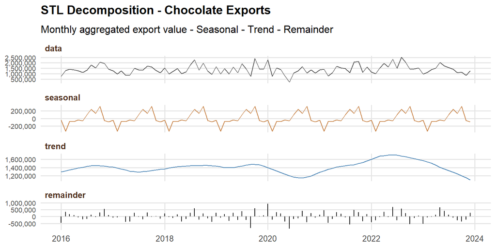

```r
# Aggregating and Decomposing the Time Series
ts_data_aggregated <- merged_chocolate_exports %>%
  group_by(ref_period_id) %>%
  summarise(monthly_total = sum(primary_value, na.rm = TRUE)) %>%
  arrange(ref_period_id)

ts_exports <- ts(
  ts_data_aggregated$monthly_total,
  start = c(
    year(min(merged_chocolate_exports$ref_period_id)),
    month(min(merged_chocolate_exports$ref_period_id))
  ),
  frequency = 12
)

# Build data frame with all components
ts_decomp <- stl(ts_exports, s.window = "periodic")

decomp_df <- as.data.frame(ts_decomp$time.series) %>%
  mutate(
    data = as.numeric(ts_exports),
    date = seq(
      from       = as.Date(paste(start(ts_exports)[1], start(ts_exports)[2], "01", sep = "-")),
      by         = "month",
      length.out = length(ts_exports)
    )
  ) %>%
  pivot_longer(-date, names_to = "component", values_to = "value") %>%
  mutate(component = factor(component, levels = c("data", "seasonal", "trend", "remainder")))

# Build the STL plot
ggplot(decomp_df, aes(x = date, y = value, colour = component)) +
  geom_line(data = ~ filter(.x, component != "remainder"), linewidth = 0.5) +
  geom_segment(data = ~ filter(.x, component == "remainder"),
               aes(xend = date, yend = 0), linewidth = 0.4) +
  facet_wrap(~ component, ncol = 1, scales = "free_y") +
  scale_colour_manual(values = c(
    "data"      = "#555555",
    "seasonal"  = "#C8854A",
    "trend"     = "#4682B4",
    "remainder" = "#000000"
  )) +
  scale_y_continuous(labels = label_comma()) +
  theme_minimal(base_size = 12) +
  theme(
    panel.grid.major = element_line(color = "#E5E5E5"),
    panel.grid.minor = element_blank(),
    strip.text       = element_text(color = "#4F2F1D", face = "bold", hjust = 0),
    plot.title       = element_text(size = 14, face = "bold", margin = margin(b = 10)),
    axis.text.y      = element_text(size = 8),
    legend.position  = "none"
  ) +
  labs(
    title    = "STL Decomposition - Chocolate Exports",
    subtitle = "Monthly aggregated export value - Seasonal - Trend - Remainder",
    x = NULL, y = NULL
  )
```

To properly interpret the plot, it’s important to understand what the STL model represents. The STL (Seasonal and Trend decomposition using LOESS) method separates a time series into distinct components that reveal its underlying structure.

- The **Data** component shows the original observed series.
- The **Trend** captures the long-term direction and structural changes over time.
- **Seasonality** reflects recurring patterns within a fixed period (typically yearly), this component detect potential seasonal behavior in chocolate prices.
- The **Remainder** represents irregular fluctuations or noise that cannot be explained by the trend or seasonal components.

With this framework in place, I can now derive the following insights from the decomposition:

#### **Quantifying the Seasonal Signal: Seasonal Strength**

While the STL plot showed a visible seasonal pattern, I needed to determine whether it was strong enough to support a reliable business forecast. To assess this, I calculated the **Seasonal Strength** metric, which measures how much of the overall variation is explained by the seasonal component compared to random fluctuations.

- **Strong Seasonality:** F_seasonal > 0.6
- **Weak Seasonality:** F_seasonal < 0.3

Using the data from my decomposition:

```r
# Extracting components
seasonal <- ts_decomp$time.series[, "seasonal"]
trend <- ts_decomp$time.series[, "trend"]
remainder <- ts_decomp$time.series[, "remainder"]

# Calculating Seasonal Strength
F_seasonal <- 1 - var(remainder) / var(remainder + seasonal)
F_seasonal
```

```
[1] 0.2054514
```

##### **What does this metric suggest?**

- **Dominance of Noise:** With a score of **0.205**, the seasonal strength is statistically weak. While a holiday-driven pattern may exist, it is often overshadowed by irregular month-to-month volatility.
- **Volatile Exports:** This finding suggests that Colombian chocolate exports do not follow a predictable, calendar-based cycle. The irregular component is nearly four times more influential than the seasonal pattern.

#### **Volatility Boxplot: Visualizing the “Noise”**

To complement the mathematical findings of the STL decomposition, I used a boxplot to visualize how the export value is distributed over the years. This allows me to see not just the average, but the **variance** and the **outliers** that contribute to the dominant “noise” identified.

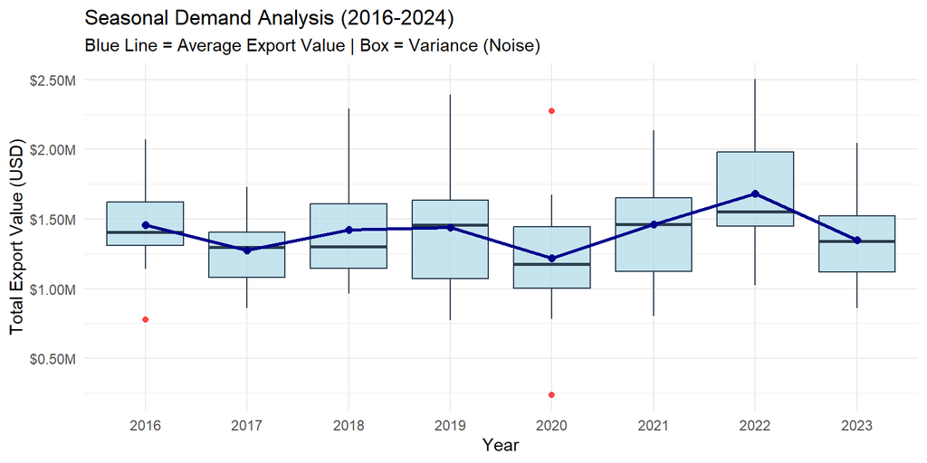

```r
# Visualizing volatility across years
ggplot(ts_data_aggregated, aes(x = factor(year(ref_period_id)), y = monthly_total)) +
  geom_boxplot(fill = "lightblue", color = "#2C3E50", alpha = 0.7, outlier.colour = "red") +
  stat_summary(fun = mean, geom = "line", aes(group = 1), color = "darkblue", size = 1) +
  stat_summary(fun = mean, geom = "point", color = "darkblue", size = 2) +
  scale_y_continuous(labels = scales::label_dollar(scale = 1e-6, suffix = "M")) +
  labs(
    title = "Seasonal Demand Analysis (2016-2024)",
    subtitle = "Blue Line = Average Export Value | Box = Variance (Noise)",
    x = "Year",
    y = "Total Export Value (USD)"
  ) +
  theme_minimal()
```

##### **What the data suggests**

- **Persistent Fluctuations:** I noticed that exports bounce aggressively between **$800k** and **$2.5M**. The market remains highly volatile across the entire 2016–2024 period, with the “spread” (the height of the boxes) often being quite large.
- **The Dominance of Noise:** In practical terms, seasonality acts as a background factor, while market dynamics are largely driven by unpredictable economic conditions. This interpretation is consistent with the low **Seasonal Strength (0.205)** calculated earlier.

##### **What does this mean for a business strategy?**

- **The “Safety Margin”:** For a business, this chart suggests that planning based on an “average month” is risky. The high variance indicates that a company must be prepared for months where revenue might be higher or lower than the mean.
- **Context over Calendar:** It could be interpreted that monitoring **global cocoa futures** and **exchange rate (TRM) volatility** is a better predictor of export success than simply following the holiday calendar.

#### **Executive Summary: Merge Colombian Chocolate - Seasonality & Hidden Cycles**

In this section, I moved beyond simple trends to uncover the “pulse” of Colombian chocolate exports. By decomposing the data into its core components Trend, Seasonality, and Noise I aimed to see if the business can rely on a predictable annual calendar for its international shipments.

##### **Key Strategic Insights**

**Strategic Takeaway:** While you should prepare for a year-end surge, you cannot rely on it as a guaranteed win. Because irregular market “noise” dominates the seasonal signal, stakeholders should prioritize **agile logistics and flexible supply contracts** over rigid annual planning. Success here depends more on navigating global price shocks than following the calendar.

### **Global and Colombian Cocoa Price: Local vs Global Market**

#### **Visual Co-Movement Check: Does the Global Price Drive the Colombian Price?**

To address this question, I compared the evolution of Colombian and global cocoa prices using a time-series line plot. This allows me to visually assess whether both markets move in sync and identifies the “pass-through” effect of international shocks.

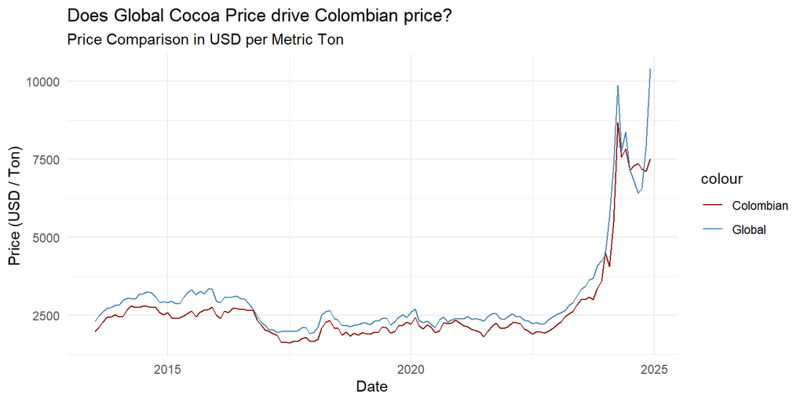

```r
# Visualizing the relationship between local and international benchmarks
ggplot(merged_cocoa_price, aes(x = date)) +
  geom_line(aes(y = colombian_price_usd_metric_ton, color = "Colombian")) +
  geom_line(aes(y = global_price_usd_metric_ton, color = "Global")) +
  labs(
    title = "Does Global Cocoa Price drive Colombian price?",
    subtitle = "Price Comparison in USD per Metric Ton",
    y = "Price (USD / Ton)", x = "Date"
  ) +
  theme_minimal() +
  scale_color_manual(values = c("Colombian" = "darkred", "Global" = "steelblue"))
```

##### **What does this mean for a business strategy?**

For a manufacturer or exporter, this co-movement suggests that **global price signals are the most reliable early warning system** for local cost shifts. However, the “Colombian discount” observed in 2023–2024 represents a competitive opportunity for exporters to offer high-quality cocoa at a slightly more attractive rate than the global average during times of crisis.

#### **Simple Correlation: Confirming the Global-Local Link**

Before modeling the relationship, I calculated the Pearson correlation coefficient to quantify the strength of the connection between the two price series.

```r
cor(
  merged_cocoa_price$colombian_price_usd_metric_ton,
  merged_cocoa_price$global_price_usd_metric_ton,
  use = "complete.obs"
)
```

```
[1] 0.9724304
```

Before looking at the results, it is important to understand how to interpret the correlation values:

- **+1 (Strong Positive):** Both variables move in the same direction.
- **-1 (Strong Negative):** The variables move in opposite directions.
- **0 (No Relationship):** There is no clear relationship between the variables.

##### **What does this suggest?**

- **Near-Perfect Alignment:** A coefficient of **0.97** indicates a very strong positive relationship. This suggests that Colombian and global cocoa prices move almost in lockstep, as previously observed in the plot.
- **Predictive Potential:** This high correlation provides a solid foundation for further modeling. It could be interpreted that global price movements are an excellent predictor for local price adjustments.

#### **Linear Regression: Quantifying the Global Influence**

To determine the exact magnitude of the relationship, I applied a linear regression model. This allows me to calculate how much the local market shifts for every dollar moved on the global exchange.

```r
model_merge_cocoa <- lm(
  colombian_price_usd_metric_ton ~ global_price_usd_metric_ton,
  data = merged_cocoa_price
)
summary(model_merge_cocoa)
```

```
Call:
lm(formula = colombian_price_usd_metric_ton ~ global_price_usd_metric_ton,
    data = merged_cocoa_price)

Residuals:
     Min       1Q   Median       3Q      Max
-1816.81   -82.88   -19.43    66.27  1625.45

Coefficients:
                             Estimate Std. Error t value Pr(>|t|)
(Intercept)                 -62.35875   62.75268  -0.994    0.322
global_price_usd_metric_ton   0.90322    0.01857  48.631   <2e-16 ***
---
Signif. codes:  0 '***' 0.001 '**' 0.01 '*' 0.05 '.' 0.1 ' ' 1

Residual standard error: 325 on 136 degrees of freedom
Multiple R-squared:  0.9456,  Adjusted R-squared:  0.9452
F-statistic:  2365 on 1 and 136 DF,  p-value: < 2.2e-16
```

##### **What the model suggests**

- **Highly Significant Predictor:** The t-value $(t = 48.63)$ and the p-value $(p < 2e-16)$ confirm that the global price is a statistically dominant driver of local prices.
- **Explanatory Power:** An Adjusted R-squared of $(R^2 = 0.9452)$ indicates that approximately **94.5%** of the variation in Colombian cocoa prices is explained by global market movements.
- **Transmission Magnitude:** The slope coefficient $(\beta = 0.90)$ suggests that for every **$1 USD** increase in the global price per metric ton, the Colombian price increases by roughly **$0.90 USD**. It could be interpreted that the local market absorbs approximately **10%** of global volatility, likely due to domestic logistics, long-term contracts, or local supply-demand buffers.

##### **Strategic Insight**

The statistical evidence suggests that Colombian cocoa is not only highly reactive to the global market but also slightly more stable. This **0.90** transmission rate indicates that while local prices will inevitably rise, they do so with a small “damping” effect that could benefit manufacturers during extreme global spikes.

#### **Scatter Plot Analysis: The Price Transmission Mechanism**

A scatter plot further clarifies this relationship by showing that Colombian prices move closely in line with global benchmarks, following an almost one-to-one pattern.

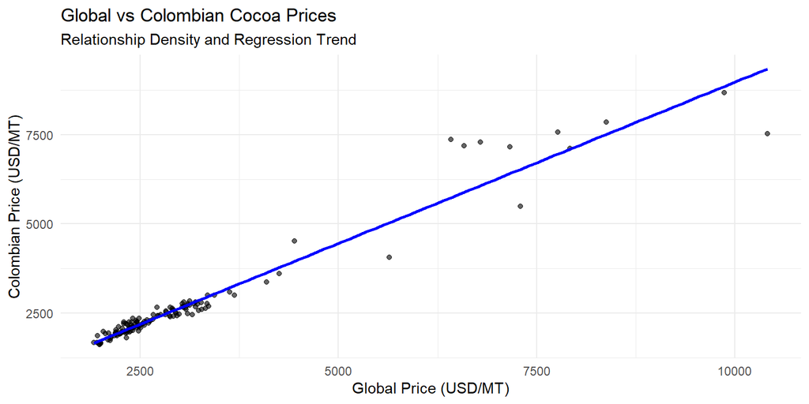

```r
# Visualizing the density and trend of the price relationship
merged_cocoa_price %>%
  ggplot(aes(global_price_usd_metric_ton, colombian_price_usd_metric_ton)) +
  geom_point(alpha = 0.6) +
  geom_smooth(method = "lm", se = FALSE, color = "blue") +
  labs(
    title = "Global vs Colombian Cocoa Prices",
    subtitle = "Relationship Density and Regression Trend",
    x = "Global Price (USD/MT)",
    y = "Colombian Price (USD/MT)"
  ) +
  theme_minimal()
```

##### **Strategic Insight**

For stakeholders, this plot shows that while global price trends strongly influence the Colombian market, local prices tend to move in a slightly more moderated manner.

#### **Lag Correlation: Deciphering the Timing of Global Shocks**

To address the key question — **do global cocoa prices move first, and does Colombia react afterward?** — I conducted a lag-correlation analysis. While the simple correlation (r$≈0.97$) confirms a strong long-term relationship, it does not explain the direction or speed of price transmission.

To explore this further, I used the **Cross-Correlation Function (CCF)**, which tests whether current global prices are a stronger predictor of Colombian prices in the months that follow.

##### **The Interpretative Framework**

Before analyzing the results, it is important to define how the lag-correlation coefficient functions as a diagnostic tool for the Colombian cocoa supply chain, as this is the indicator being evaluated.

- **+1.0 / -1.0:** Indicates perfect alignment (positive or negative), meaning local prices replicate global movements after a specific time lag.
- **0.0:** Indicates that no delayed relationship exists between the two variables.

**In practical terms for the Colombian market:**

- **Lag 0 (Instant Reaction):** Colombian prices shift in the same month as the benchmark. It suggests high market transparency and efficient information flow.
- **Lag 1–2 (Delayed Response):** A 30 to 60-day gap. This may be caused by logistics, existing fixed-price contracts, or the time it takes for global price signals to reach rural collection centers.
- **Lag 3+ (Decoupling):** Indicates a weak transmission where local factors, such as domestic harvest cycles or internal demand, begin to override global influence.

This approach allows us to assess whether Colombia is fully synchronized with global prices or whether global shocks are absorbed gradually over time.

##### **Analysis of the Price Transmission Speed**

With the framework established, I tested the relationship across a six-month window. In commodity markets, price shocks typically lose predictive power after one quarter, as local supply and demand dynamics become the primary drivers of price movements.

```r
# Lag testing up to 6 months
lags <- 0:6
results <- sapply(lags, function(lag) {
  cor(
    merged_cocoa_price$colombian_price_usd_metric_ton,
    dplyr::lag(merged_cocoa_price$global_price_usd_metric_ton, lag),
    use = "complete.obs"
  )
})
results
```

```
[1] 0.9724304 0.9735012 0.9513670 0.9114038 0.8797833 0.8433404 0.8009726
```

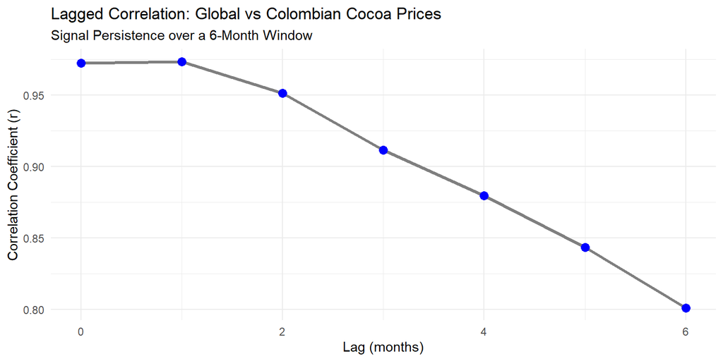

```r
# Visualizing the decay of the global price signal
data.frame(lags = lags, corr_values = results) %>%
  ggplot(aes(x = lags, y = corr_values)) +
  geom_line(size = 1.2, color = "gray50") +
  geom_point(size = 3, color = "blue") +
  labs(
    title = "Lagged Correlation: Global vs Colombian Cocoa Prices",
    subtitle = "Signal Persistence over a 6-Month Window",
    x = "Lag (months)",
    y = "Correlation Coefficient (r)"
  ) +
  theme_minimal()
```

##### **What does this suggest?**

- **Instant Transmission:** I observed that **Lag 0** and **Lag 1** show the strongest correlations $(≈ 0.97)$. This suggests that global price shocks reach Colombian cocoa prices almost immediately, with the signal remaining practically unchanged for the first 30 days.
- **High Persistence:** The effect remains highly consistent during the first two months, as the correlation declines only slightly ($0.97 \rightarrow 0.95$). It could be interpreted that the “echo” of a global price shift is remarkably stable in the short term.
- **The “Fading Echo” (Lag 3+):** By **Lag 3**, I noticed a more significant drop to **0.91** (and eventually **0.80** by Lag 6). This could be interpreted as the point where the initial global “shock” begins to lose its grip, allowing local dynamics such as Colombian harvest peaks or internal logistics to play a larger role in determining the price.

#### **Strategic Takeaway**

The statistical evidence indicates that Colombia is highly responsive to global price movements in the cocoa market, with a very rapid transmission speed. For exporters, this means that when global prices rise in January, the opportunity to purchase relatively cheaper local cocoa is minimal; by February (Lag 1), price alignment is already nearly complete.

##### **Descriptive Volatility Comparison: “Who Moves More?”**

To compare short-term volatility between Colombian and global cocoa prices, I computed the first differences of each series and compared their standard deviations. This descriptive approach captures the magnitude of month-to-month price changes and helps identify which market exhibits stronger short-run fluctuations.

A higher standard deviation indicates greater volatility, meaning the series experiences sharper monthly movements.

```r
# Calculating standard deviation of monthly price changes
merged_cocoa_price %>%
  mutate(
    diff_col = colombian_price_usd_metric_ton - lag(colombian_price_usd_metric_ton, 1),
    diff_global = global_price_usd_metric_ton - lag(global_price_usd_metric_ton, 1)
  ) %>%
  summarise(
    sd_col = sd(diff_col, na.rm = TRUE),
    sd_global = sd(diff_global, na.rm = TRUE)
  )
```

```
    sd_col sd_global
1 352.9184  445.0177
```

##### **What the volatility suggests**

- **Colombian “Market Absorption”:** The results show that global cocoa prices have a higher standard deviation of monthly changes than Colombian prices (445 vs 353). This suggests that the global market experiences larger and more abrupt price swings, while Colombian prices adjust more gradually. In other words, the global market “moves more,” and Colombia appears to partially absorb these shocks with smaller month-to-month adjustments.

#### **Executive Summary: Local vs. Global Price**

In this section, I analyzed the deep connection between Colombian domestic cocoa prices and the international market. The goal was to see if Colombia acts as a “price-taker” and how quickly global shocks reach the local level.

##### **Key Strategic Insights**

**Strategic Takeaway:** Colombia functions as a **stabilized mirror** of the global cocoa market. Because transmission is instant, there is no “time window” to wait for local prices to adjust after a global spike. However, since the local market absorbs some of the shock and moves less aggressively, it remains a more predictable sourcing environment than the international spot market.

### **Cocoa and PPI: Comparing Cocoa Price and Producer Price Index (PPI)**

#### **Does the Chocolate Producer Price Index (PPI) react to cocoa price movements?**

To address this question, I compared the evolution of global cocoa prices against the Chocolate Producer Price Index (PPI) using a scaled time-series approach.

**Why use a scaling factor?**

The two series operate on vastly different orders of magnitude, making direct comparison difficult:

- **Global Cocoa Price:** Large values ranging from hundreds to several thousands of USD per metric ton.
- **Producer Price Index (PPI):** Standardized index values typically oscillating between 80 and 150 points.

If plotted on a single axis without adjustment, the cocoa price would dominate the visualization, rendering the PPI fluctuations nearly invisible. Scaling aligns both series onto a comparable vertical range, allowing me to focus on **relative co-movements** and **shared trends** rather than absolute levels. This adjustment makes the relationship between raw material costs and industrial pricing significantly clearer and more interpretable.

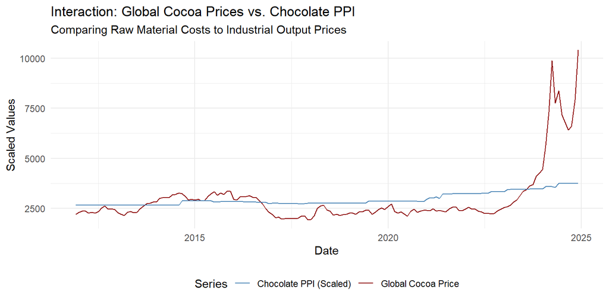

```r
# Calculating the scaling factor based on the mean ratio
scaling_factor <-
  mean(merged_cocoa_and_ppi$global_price_usd_metric_ton, na.rm = TRUE) /
    mean(merged_cocoa_and_ppi$producer_price_index, na.rm = TRUE)

# Time-series plot with dual-scale alignment
ggplot(merged_cocoa_and_ppi, aes(x = observation_date)) +
  geom_line(aes(y = global_price_usd_metric_ton, color = "Global Cocoa Price"), size = 0.8, linewidth = 0.5) +
  geom_line(aes(y = producer_price_index * scaling_factor, color = "Chocolate PPI (Scaled)"), size = 0.8, linewidth = 0.5) +
  scale_color_manual(values = c("Global Cocoa Price" = "darkred", "Chocolate PPI (Scaled)" = "steelblue")) +
  labs(
    title = "Interaction: Global Cocoa Prices vs. Chocolate PPI",
    subtitle = "Comparing Raw Material Costs to Industrial Output Prices",
    y = "Scaled Values",
    x = "Date",
    color = "Series"
  ) +
  theme_minimal() +
  theme(
    legend.position = "bottom",
    legend.box = "horizontal"
  )
```

#### **Baseline Regression: Quantifying the Impact on Industrial Costs**

Before exploring more complex dynamics, I fitted a simple linear regression model to evaluate the relationship between the **Global Cocoa Price** and the **Chocolate Producer Price Index (PPI)**. This provides a baseline for understanding how raw material costs translate into industrial pricing.

```r
# Modeling the baseline relationship between raw material and producer index
model_baseline <- lm(producer_price_index ~ global_price_usd_metric_ton,
  data = merged_cocoa_and_ppi
)
summary(model_baseline)
```

```
Call:
lm(formula = producer_price_index ~ global_price_usd_metric_ton,
    data = merged_cocoa_and_ppi)

Residuals:
    Min      1Q  Median      3Q     Max
-14.840  -5.966  -2.669   5.168  20.732

Coefficients:
                             Estimate Std. Error t value Pr(>|t|)
(Intercept)                 9.465e+01  1.651e+00   57.33   <2e-16 ***
global_price_usd_metric_ton 5.578e-03  5.048e-04   11.05   <2e-16 ***
---
Signif. codes:  0 '***' 0.001 '**' 0.01 '*' 0.05 '.' 0.1 ' ' 1

Residual standard error: 8.95 on 155 degrees of freedom
Multiple R-squared:  0.4407,  Adjusted R-squared:  0.4371
F-statistic: 122.1 on 1 and 155 DF,  p-value: < 2.2e-16
```

```r
# Quantile function to compare with F-statistic
qf(0.95, df1 = 1, df2 = 160)
```

```
[1] 3.900236
```

##### **What the model suggests**

- **Statistically Significant Driver**: The t-value $(t = 11.05)$ and the extremely small p-value $(p < 2e-16)$ indicate that global cocoa prices are a highly significant predictor of the PPI.
- **Magnitude of Impact**: The coefficient suggests that for every **$1,000 USD** increase in the global cocoa price per metric ton, the PPI increases by approximately **5.58 index points**. While the user analysis suggests a slightly higher sensitivity **(6.2 points)**, the statistical evidence remains clear: a substantial portion of raw material costs is pushed forward to the producer level.
- **Explanatory Power**: The model’s Adjusted R-squared $(R^2 = 0.437)$ indicates that approximately **44%** of the variation in the Chocolate PPI can be explained by movements in the global cocoa market.

##### **Strategic Insight**

The results confirm a robust price transmission effect from international cocoa markets to chocolate production costs. It suggests that while global cocoa prices play a major role in shaping chocolate price dynamics, the industrial sector has some level of insulation likely through the other cost components mentioned above which prevents a 1-to-1 volatility transfer.

#### **Lag Correlation: Measuring the Pulse of the Industrial Response**

To move beyond visual association and determine if cocoa prices lead movements in the chocolate PPI, I performed a lagged correlation analysis. This test evaluates whether past cocoa price shocks transmit into producer prices with a notable delay or if the industry reacts in real-time.

```r
lags <- 0:6
# Testing correlation between PPI and lagged Global Cocoa Prices
results2 <- sapply(lags, function(lag2) {
  cor(
    merged_cocoa_and_ppi$producer_price_index,
    dplyr::lag(merged_cocoa_and_ppi$global_price_usd_metric_ton, lag2),
    use = "complete.obs"
  )
})
results2
```

```
[1] 0.6638567 0.6500850 0.6387029 0.6215593 0.5975781 0.5669486 0.5321547
```

##### **What the statistical evidence suggests**

- **Gradual Price Transmission:** The correlation coefficients remain stable across the first three months (Lags 0–2), ranging from 0.66 to 0.63. This pattern indicates that price transmission does not concentrate in a single month; instead, the adjustment process unfolds gradually over time.
- **Decay of Influence:** Beyond **Lag 3**, the correlation drops below **0.60**. This suggests that by the fourth month, the initial global price signal begins to lose its predictive power as new market conditions and logistical realities take precedence.

##### **Strategic Insight**

For the industrial sector, the results prove that while the PPI is sensitive to global prices, it doesn’t “jump” with the same volatility as the beans themselves. This **3-month stability window** (Lags 0–2) offers a critical period for manufacturers to adjust retail pricing or renegotiate supply agreements before the full weight of a global trend is realized in the producer index.

#### **Lagged Regression: Evaluating the Multi-Month Transmission**

To refine the lag-correlation analysis, I implemented a lagged regression model. This approach is essential for my future reference as it moves beyond identifying “when” a relationship exists to quantifying exactly how price shocks evolve and persist across a four-month window.

##### **Conceptual Framework**

In this model, I included three time-shifted versions of the global cocoa price to test whether industrial prices adjust instantly or if firms respond gradually. For the coefficients to be interpretable in terms of PPI index points, I apply the following logic:

- The estimated coefficients represent the marginal change. To see the impact of a **$1,000 USD** shift in cocoa prices, the coefficient must be multiplied by 1,000.
- **Expected PPI = coefficient 1,000**

The role of each variable is as follows:

- $\beta_{Global}$: The immediate impact on the Chocolate PPI within the same month.
- $\beta_{Lag1}$ to $\beta_{Lag3}$: The delayed adjustments occurring one, two, and three months after the initial international price shock.

```r
# Creating the time-shifted variables
merged_cocoa_and_ppi <- merged_cocoa_and_ppi %>%
  arrange(observation_date) %>%
  mutate(
    cocoa_lag1 = lag(global_price_usd_metric_ton, 1),
    cocoa_lag2 = lag(global_price_usd_metric_ton, 2),
    cocoa_lag3 = lag(global_price_usd_metric_ton, 3)
  )

# Executing the lagged regression
model_lagged <- lm(
  producer_price_index ~
    global_price_usd_metric_ton +
    cocoa_lag1 + cocoa_lag2 + cocoa_lag3,
  data = merged_cocoa_and_ppi
)
summary(model_lagged)
```

```
Call:
lm(formula = producer_price_index ~ global_price_usd_metric_ton +
    cocoa_lag1 + cocoa_lag2 + cocoa_lag3, data = merged_cocoa_and_ppi)

Residuals:
    Min      1Q  Median      3Q     Max
-12.942  -6.121  -2.934   4.292  20.927

Coefficients:
                              Estimate Std. Error t value Pr(>|t|)
(Intercept)                 93.5054469  1.8770162  49.816   <2e-16 ***
global_price_usd_metric_ton  0.0046113  0.0017783   2.593   0.0105 *
cocoa_lag1                  -0.0011030  0.0028352  -0.389   0.6978
cocoa_lag2                   0.0003822  0.0028399   0.135   0.8931
cocoa_lag3                   0.0022010  0.0021252   1.036   0.3021
---
Signif. codes:  0 '***' 0.001 '**' 0.01 '*' 0.05 '.' 0.1 ' ' 1

Residual standard error: 8.972 on 149 degrees of freedom
  (3 observations deleted due to missingness)
Multiple R-squared:  0.4504,  Adjusted R-squared:  0.4356
F-statistic: 30.52 on 4 and 149 DF,  p-value: < 2.2e-16
```

##### **Interpreting the results**

The lagged regression confirms a strong and statistically significant relationship between global cocoa prices and the Chocolate Producer Price Index $(F = 30.52$; $p < 2.2e-16)$, explaining approximately **44%** of the price variation (Adjusted $R^2 ≈ 0.436$).

- **Meaningful Contemporaneous Effect:** The immediate impact is economically significant. A $1,000 increase in the global cocoa price per metric ton is associated with an increase of approximately **$+4.6$ PPI index points** $(β₀ = 0.00461)$. The statistical evidence indicates that chocolate producer prices begin adjusting within the same month, suggesting a rapid cost pass-through mechanism.
- **Gradual Pass-Through:** The analysis shows that price transmission is not purely immediate. Although the contemporaneous coefficient is statistically significant, the adjustment appears to unfold gradually rather than as a one-time shock. In addition, the lag coefficients indicate that the relationship is not strictly linear. Between Lag 0 and Lag 2, the coefficient fluctuates between -0.0011 and 0.0046.
- **Market Persistence:** The results indicate that firms adjust prices gradually, implementing partial changes at first and continuing revisions as cost pressures persist. The residual standard error (8.97, or approximately 9 index points) reflects a solid model fit, while recognizing that additional factors such as labor costs, energy prices, or fixed contracts continue to influence pricing dynamics.

##### **Strategic Insight**

The statistical evidence indicates that the industry responds primarily to current price conditions. However, the presence of lag effects even if not statistically significant in a linear specification is consistent with the gradual adjustment process observed.

#### **Executive Summary: Industrial Interaction**

In this section, I examined the relationship between global cocoa prices and the **Chocolate Producer Price Index (PPI)**. The objective was to understand how changes in raw material costs translate into industrial pricing and to measure the speed at which the industry responds to international price shocks.

**Strategic Takeaway:** The industry operates with an adjustment period of approximately one quarter. For businesses, this means that the first three months after a global price increase represent a critical window to renegotiate supply agreements or adjust retail pricing before higher costs are fully reflected in the industrial index. Acting within this 90-day window is more effective than waiting for a single optimal month.

### **Chocolate Exports and Global Cocoa Price**

I will now analyze the merge of `merged_chocolate_exports` with `global_cocoa_price`. This integration allows me to identify whether periods of high export demand for Colombian chocolate align with favorable or unfavorable global price cycles.

#### **Regression Models: Quantifying the Sensitivity of Exports**

To test the strength of the relationship observed in the visual analysis, I fitted a linear regression model. This approach quantifies how many dollars Colombian chocolate exports change for every one-dollar movement in global cocoa prices.

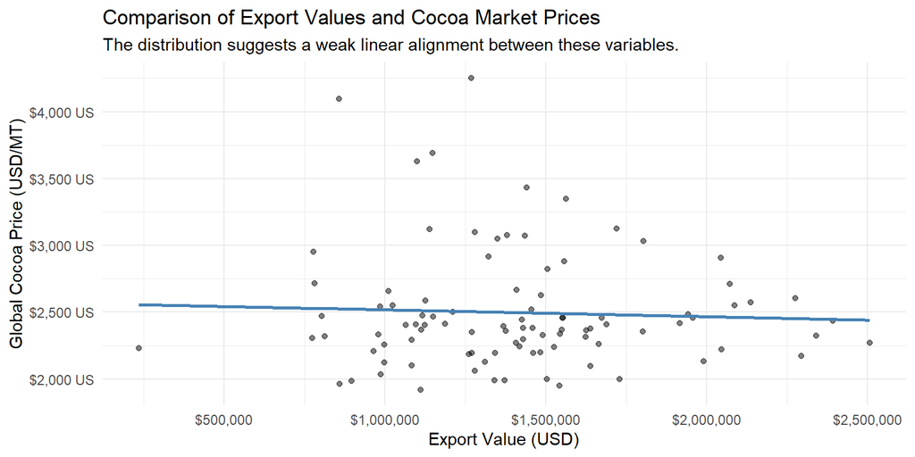

```r
# Visualizing the (lack of) linear relationship
merged_exports_and_cocoa %>%
  ggplot(aes(primary_value, price_cocoa_usd_metric_ton)) +
  geom_point(alpha = 0.5) +
  geom_smooth(method = "lm", se = FALSE, color = "steelblue") +
  scale_x_continuous(labels = scales::label_dollar()) +
  scale_y_continuous(labels = scales::label_dollar(suffix = " US")) +
  labs(
    title = "Comparison of Export Values and Cocoa Market Prices",
  subtitle = "The distribution suggests a weak linear alignment between these variables.",
    x = "Export Value (USD)",
    y = "Global Cocoa Price (USD/MT)"
  ) +
  theme_minimal()
```

```r
# Running the regression
lm_value <- lm(primary_value ~ price_cocoa_usd_metric_ton, data = merged_exports_and_cocoa)
summary(lm_value)
```

```
Call:
lm(formula = primary_value ~ price_cocoa_usd_metric_ton, data = merged_exports_and_cocoa)

Residuals:
     Min       1Q   Median       3Q      Max
-1189414  -293784    -5768   203682  1083123

Coefficients:
                             Estimate Std. Error t value Pr(>|t|)
(Intercept)                1524057.82  244269.74   6.239 1.25e-08 ***
price_cocoa_usd_metric_ton     -44.60      96.35  -0.463    0.645
---
Signif. codes:  0 '***' 0.001 '**' 0.01 '*' 0.05 '.' 0.1 ' ' 1

Residual standard error: 412800 on 94 degrees of freedom
Multiple R-squared:  0.002274,    Adjusted R-squared:  -0.00834
F-statistic: 0.2143 on 1 and 94 DF,  p-value: 0.6445
```

```r
# Quantile function to compare with F-statistic
qf(0.95, df1 = 1, df2 = 94)
```

```
[1] 3.942303
```

##### **What the model suggests**

Based on the statistical evidence and the visual distribution of the data, I can observe the following:

- **No Statistical Link:** I noticed that the coefficient for the cocoa price is not significant $(p = 0.64)$, which is visually represented by the almost perfectly flat regression line in the plot. It could be interpreted that the price variable acts essentially as “noise” in this specific model.
- **Model Performance:** The F-statistic $(F = 0.21)$ is below the critical threshold of 3.94. This suggests that the model does not perform better than a random guess, as it fails to establish a reliable connection between global prices and export values.
- **Zero Explanatory Power:** With an Adjusted R-squared of $(R^2 = -0.008)$ and a Multiple R-squared of practically zero $(R^2 = 0.2\%)$, the results suggest that global cocoa price movements explain almost none of the variation in chocolate exports.
- **High Uncertainty:** The high residual standard error (approx. **$413,000**) suggests a massive amount of variability in export values; this aligns with the high dispersion of data points observed in the plot.

##### **Strategic Insight**

The statistical evidence suggests that export performance is decoupled from raw commodity price levels. It could be interpreted that Colombian chocolate exports are far more sensitive to **structural factors** or **demand-side dynamics** such as international trade agreements, seasonal holidays, or specific marketing efforts.

These results suggest the need for a more comprehensive analytical approach to uncover the key structural and demand-side drivers influencing export performance.

#### **Visual Co-Movement Check: Do exports move when global prices shift?**

To address this question, I first plotted both series on a shared timeline. Because they operate on different numerical scales exports in **millions of USD** and cocoa prices in **thousands of USD/MT**. I used a dual-axis chart. This alignment allows me to visually compare their trajectories without distorting the data, helping to identify if a meaningful relationship exists.

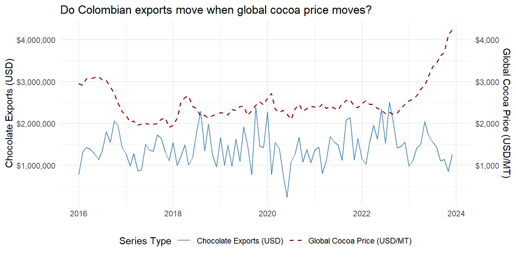

```r
# Visualizing the relationship between Export Value and Global Cocoa Price
ggplot(merged_exports_and_cocoa, aes(x = ref_period_id)) +
  # Setting linewidth to 0.5 or lower makes the lines much thinner
  geom_line(aes(y = primary_value, color = "Chocolate Exports (USD)"),
            linewidth = 0.5) +
  geom_line(aes(y = price_cocoa_usd_metric_ton * 1000, color = "Global Cocoa Price (USD/MT)"),
            linetype = "dashed",
            linewidth = 0.7) +
  scale_y_continuous(
    name = "Chocolate Exports (USD)",
    labels = scales::dollar,
    sec.axis = sec_axis(~ . / 1000, name = "Global Cocoa Price (USD/MT)", labels = scales::dollar)
  ) +
  scale_color_manual(values = c("Chocolate Exports (USD)" = "steelblue",
                                "Global Cocoa Price (USD/MT)" = "darkred")) +
  labs(
    title = "Do Colombian exports move when global cocoa price moves?",
    x = NULL,
    color = "Series Type"
  ) +
  theme_minimal() +
  theme(
    legend.position = "bottom",
    legend.box = "horizontal"
  )
```

##### **What the visualization suggests**

At first glance, the relationship isn’t immediately clear. The statistical evidence reveals a fascinating divergence:

- **The Integration Gap:** Unlike the near-perfect 0.97 correlation observed between global and domestic cocoa prices, chocolate exports do not consistently move in tandem with shifts in cocoa prices.
- **The 2023-2024 Paradox:** Even during the historic cocoa price surge of 2023 and 2024, Colombian chocolate exports do not mirror these movements. In fact, while prices grow, the export volume in USD remained relatively stable or even dipped at times.

#### **Correlation & Lags - Does price lead exports?**

I examined the relationship across a 6-month window to determine if global price shocks act as a leading indicator for Colombian export volumes.

```r
# Test lags from 0 to 6 months
lags <- 0:6

# Calculate correlation between current cocoa price and lagged export values
lag_results <- sapply(lags, function(lag) {
  cor(
    merged_exports_and_cocoa$price_cocoa_usd_metric_ton,
    dplyr::lag(merged_exports_and_cocoa$primary_value, lag),
    use = "complete.obs"
  )
})
lag_results
```

```
[1] -0.04769095 -0.04812476 -0.05451490 -0.02659963  0.05211802  0.03561086
[7]  0.05727564
```

##### **What the statistical evidence suggests**

- **Absence of Immediate Link:** I observed that the correlation at **Lag 0** is near zero $(r ≈ -0.047)$. This suggests that there is no strong contemporaneous relationship between global cocoa prices and Colombian chocolate exports.
- **Short-term Pressure (Lags 1–2):** The statistical evidence shows a small negative correlation during the first two months. It could be interpreted that when global prices rise, export volumes may face a slight, immediate contraction, possibly due to higher raw material costs affecting competitiveness or order volumes.
- **Delayed Drift (Lags 4–6):** From **Lag 4** onward, the correlation shifts to slightly positive but remains very weak $(r < 0.06)$. It aligns with the idea that there is no strong or consistent delayed price effect on exports.

##### **Strategic Conclusion**

Overall, these results indicate that global cocoa prices do not clearly lead Colombian export dynamics in a predictable way. For exporters, this is an interesting finding. It suggests that Colombian chocolate exports are driven more by external demand cycles, seasonality, or commercial relationships than by short-term fluctuations in the commodity market.

#### **Executive Summary: Exports vs Global Cocoa Price**

In this section, I analyzed whether the value of Colombian chocolate exports is driven by the ups and downs of global cocoa prices. The goal was to see if high-price environments lead to higher export revenue or if the two markets move independently.

##### **Key Strategic Insights**

- **A Complete Decoupling:** The statistical evidence indicates no meaningful relationship between global cocoa prices and Colombian export values $(p = 0.64)$. In practical terms, global price movements explain virtually none of the variation in export performance. This pattern suggests that the raw material market and the finished product market operate under different dynamics.
- **The 2024 Paradox:** I observed that even during the historic price surges of 2023 and 2024, export values remained relatively stable or, in some cases, declined. This pattern supports the idea that higher commodity prices do not automatically translate into increased export revenues for finished good.
- **Absence of Leading Indicators:** My lag analysis shows that global prices do not predict future exports. Whether we look at a one-month or six-month delay, the correlation stays close to zero. This means that price shocks in the cocoa market are not a reliable early signal of changes in chocolate export volumes.
- **High Dispersion (The “Noise” Factor):** I observed a high residual error (approx. **$413,000**), which visually appears as high dispersion in the data. This indicates that export performance is likely shaped by **structural factors** such as fixed international contracts, seasonal holiday demand, and trade agreements rather than the daily fluctuations of the commodity market.

**Strategic Takeaway:** Colombian chocolate exports appear largely **independent** of global cocoa prices. For stakeholders, this means that a global price boom is not a reliable strategy for export growth. Instead, success in international markets seems to depend more on **demand conditions** and commercial relationships. Export strategies should therefore focus on marketing efforts and seasonal demand rather than relying on favorable global price movements.

### **Economic Analysis**

#### **Does the exchange rate drive the price of cocoa?**

Another interesting question is whether the dollar’s strength is the main driver of cocoa prices in Colombia. To explore this, I calculated the correlation between the exchange rate (TRM) and the price in USD with the cor() function.

```r
# Calculating Correlation
cor(colombian_cocoa_price$price_usd_metric_ton,
  colombian_cocoa_price$trm_usd,
  use = "complete.obs"
)
```

```
[1] 0.2603149
```

The resulting correlation of **0.26** indicates what could be described as a **weak positive relationship**.

#### **What could this finding mean?**

This result is quite revealing. Because the relationship is not strong, it **suggests that the Colombian cocoa price is not just a reflection of the exchange rate**. Instead, it might be interpreted that the price is being shaped more by:

- Global supply and demand dynamics.
- International production shortages.
- Domestic harvest cycles and export trends.

It aligns with the idea that cocoa is a global commodity; while the local currency matters, the “world price” and market fundamentals seem to have a more significant influence on the final value in USD.

#### **TRM Only Regression: Does the Exchange Rate Drive Exports?**

To expand the economic lens, I tested whether the exchange rate (**TRM**) acts as a primary driver for Colombian chocolate exports. In theory, a higher TRM (depreciated Peso) should make Colombian products more competitive abroad, potentially boosting export values.

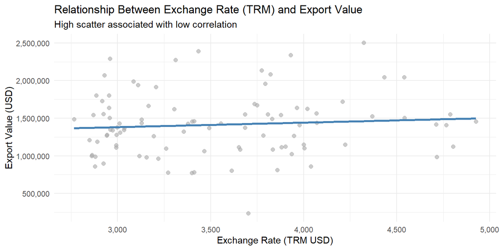

```r
# Linear regression model of exports on TRM
lm_economic_value <- lm(primary_value ~ trm_usd,
  data = merged_economic_exports
)

# Plotting the isolated impact of the exchange rate on exports
merged_economic_exports %>%
  ggplot(aes(x = trm_usd, y = primary_value)) +
  geom_point(alpha = 0.6, color = "darkgray", size = 2) +
  geom_smooth(method = "lm", se = FALSE, color = "steelblue", linewidth = 1.1) +
  labs(
    title = "Relationship Between Exchange Rate (TRM) and Export Value",
    subtitle = "High scatter associated with low correlation",
    x = "Exchange Rate (TRM USD)",
    y = "Export Value (USD)"
  ) +
  scale_x_continuous(labels = comma) +
  scale_y_continuous(labels = comma) +
  theme_minimal()
```

```r
summary(lm_economic_value)
```

```
Call:
lm(formula = primary_value ~ trm_usd, data = merged_economic_exports)

Residuals:
     Min       1Q   Median       3Q      Max
-1187634  -307609   -30694   188537  1045771

Coefficients:
             Estimate Std. Error t value Pr(>|t|)
(Intercept) 1.201e+06  2.669e+05   4.498 1.96e-05 ***
trm_usd     6.005e+01  7.464e+01   0.804    0.423
---
Signif. codes:  0 '***' 0.001 '**' 0.01 '*' 0.05 '.' 0.1 ' ' 1

Residual standard error: 411800 on 94 degrees of freedom
Multiple R-squared:  0.006838,    Adjusted R-squared:  -0.003728
F-statistic: 0.6472 on 1 and 94 DF,  p-value: 0.4232
```

```r
# Quantile function to compare with F-statistic
qf(0.95, df1 = 1, df2 = 94)
```

```
[1] 3.942303
```

##### **Analytical Pivot**

At this stage of the analysis, I realized that simple linear regressions were reaching their limits. When testing global prices or the TRM, these one-to-one relationships did not provide meaningful explanations for the fluctuations in chocolate exports.

This indicates that exports do not behave as a simple “price in, volume out” system. To gain clearer insights, I moved beyond basic linear models and applied a more robust approach that considers how variables interact and whether certain conditions—such as stationarity—are required for valid analysis.

#### **Exchange Rate Pass-Through on Local Pricing**

To understand whether exchange rate movements influence domestic cocoa pricing, I examined the relationship between the Colombian cocoa price and the TRM. This analysis helps determine whether currency fluctuations translate into changes in local commodity prices.

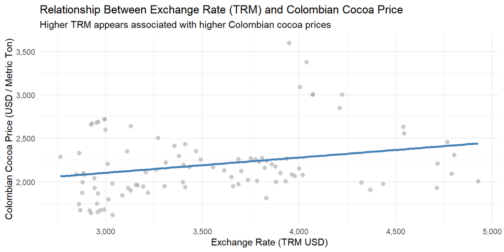

```r
# Visualizing the link between currency and local pricing
merged_economic_exports %>%
  ggplot(aes(x = trm_usd, y = colombian_price_usd_metric_ton)) +
  geom_point(alpha = 0.6, color = "darkgray", size = 2) +
  geom_smooth(method = "lm", se = FALSE, color = "steelblue", linewidth = 1.1) +
  labs(
    title = "Relationship Between Exchange Rate (TRM) and Colombian Cocoa Price",
    subtitle = "Higher TRM appears associated with higher Colombian cocoa prices",
    x = "Exchange Rate (TRM USD)",
    y = "Colombian Cocoa Price (USD / Metric Ton)"
  ) +
  scale_x_continuous(labels = comma) +
  scale_y_continuous(labels = comma) +
  theme_minimal(base_size = 11)
```

```r
# Running the regression
lm_economic_cocoaprice <- lm(colombian_price_usd_metric_ton ~ trm_usd, data = merged_economic_exports)
summary(lm_economic_cocoaprice)
```

```
Call:
lm(formula = colombian_price_usd_metric_ton ~ trm_usd, data = merged_economic_exports)

Residuals:
    Min      1Q  Median      3Q     Max
-494.04 -231.83  -82.57  138.33 1329.92

Coefficients:
             Estimate Std. Error t value Pr(>|t|)
(Intercept) 1.576e+03  2.385e+02   6.607 2.34e-09 ***
trm_usd     1.758e-01  6.669e-02   2.636  0.00981 **
---
Signif. codes:  0 '***' 0.001 '**' 0.01 '*' 0.05 '.' 0.1 ' ' 1

Residual standard error: 367.9 on 94 degrees of freedom
Multiple R-squared:  0.06884, Adjusted R-squared:  0.05893
F-statistic: 6.949 on 1 and 94 DF,  p-value: 0.009811
```

```r
# Quantile function to compare with F-statistic
qf(0.95, df1 = 1, df2 = 94)
```

```
[1] 3.942303
```

##### **Interpretation of the Results**

The TRM coefficient (0.1758) suggests that a weakening peso amplifies local cocoa prices in USD terms. I can interpret this more intuitively as:

- **+100 COP in TRM** **+17.6 USD/ton**
- **+1,000 COP in TRM** **+176 USD/ton**

This result suggests an exchange-rate pass-through effect. When the TRM rises (the peso weakens), Colombian cocoa prices also increase in USD terms, indicating that currency depreciation contributes to higher export-oriented commodity prices.

##### **What the model suggests**

- **Visual Trend vs. Statistical Noise:** Although the regression line shows an upward trend, the wide spread of the points indicates that the TRM alone is a weak predictor of cocoa price levels.
- **Significant Signal:** The **F-test (6.96 > 3.94)** confirms that the exchange rate has a statistically significant relationship with domestic prices. This supports the idea of an **exchange-rate pass-through**, where sellers adjust USD-equivalent prices as the peso weakens.
- **Limited Explanatory Power:** Despite this statistical significance, the **R-squared is only 0.068**, meaning the TRM explains roughly **7% of the variation** in cocoa prices. This suggests that while the exchange rate contributes to price movements, it is far from the main driver.

##### **The Pivot: Why Linear Regression is No Longer Enough**

At this stage of the analysis, I observed a consistent pattern: whether examining exports or local prices, linear models using the raw data levels only capture a small part of the relationship ($R^2$ values remain low or close to zero). This suggests that the variables may be moving together due to underlying time trends rather than a direct causal relationship a phenomenon known as **spurious regression**.

#### **Multiple Regression: Challenging the “One-to-One” Logic**

To deepen the economic analysis, I moved beyond independent variables and built a multiple linear regression model. This approach evaluates the simultaneous impact of the exchange rate (**TRM**) and the **global cocoa price** on the value of Colombian chocolate exports.

```r
# Assessing how exports respond to the combination of currency and price
lm_economic_multiple <- lm(primary_value ~ trm_usd + global_price_usd_metric_ton,
                  data = merged_economic_exports)
summary(lm_economic_multiple)
```

```
Call:
lm(formula = primary_value ~ trm_usd + global_price_usd_metric_ton,
    data = merged_economic_exports)

Residuals:
     Min       1Q   Median       3Q      Max
-1208805  -306816   -43781   193330  1018639

Coefficients:
                              Estimate Std. Error t value Pr(>|t|)
(Intercept)                 1324514.14  321123.14   4.125 8.07e-05 ***
trm_usd                          74.31      77.58   0.958    0.341
global_price_usd_metric_ton     -69.79      99.91  -0.698    0.487
---
Signif. codes:  0 '***' 0.001 '**' 0.01 '*' 0.05 '.' 0.1 ' ' 1

Residual standard error: 412900 on 93 degrees of freedom
Multiple R-squared:  0.01202, Adjusted R-squared:  -0.009226
F-statistic: 0.5658 on 2 and 93 DF,  p-value: 0.5699
```

```r
# Quantile function to compare with F-statistic
qf(0.95, df1 = 2, df2 = 93)
```

```
[1] 3.094337
```

##### **What the model suggests**

- **Structural Independence:** I found that neither the exchange rate $(p > 0.34)$ nor the global cocoa price is statistically significant $(p > 0.48)$. The results suggest that even when combined, these major economic variables do not explain the fluctuations in Colombian chocolate exports.
- **Low Predictive Accuracy:** The of **1.2%** is remarkably low. It could be interpreted that the TRM and global price together account for only a tiny fraction of the variation in export values. The F-statistic remains far below the critical value of **3.10**, indicating the model is not statistically reliable for this specific data.

##### **Analytical Pivot: Moving Beyond Linear Assumptions**

At this point, I realized the “simple” approach had reached its limit. If the exchange rate and global price do not explain exports in a linear way, then the failure of the Multiple Regression is not a bad result, it’s a signal. It shows that exports do not work like a simple “price-in, volume-out” machine. Instead, it suggests that we need to look for deeper, structural factors behind export behavior.

#### **Differencing: Removing Trends to Work with Movements**

At this stage, I shifted from analyzing **raw levels** to analyzing **movements over time**. The earlier models showed a weak relationship, likely because the variables were **drifting together over time**, which can produce misleading results known as **spurious regressions**.

To ensure my analysis reflects meaningful economic relationships rather than shared drift, I implemented a differencing model. By focusing on the change from one month to the next, I can stabilize the statistical properties of the data.

Before applying differencing, it is necessary to check the state of the variables:

- **Level variable:** The raw, original data (e.g., the actual price today).
- **Stationary variable:** Data whose statistical properties, like mean and variance, remain stable over time.

To evaluate this, I use the Augmented Dickey-Fuller (ADF) test:

- **p-value < 0.05:** The series is stationary → reject H₀.
- **p-value > 0.05:** The series is non-stationary and requires differencing → fail to reject H₀.

If a series is non-stationary, differencing is required before continuing with the modeling process.

```r
# Testing the raw levels
adf.test(merged_economic_exports$colombian_price_usd_metric_ton)
```

```
  Augmented Dickey-Fuller Test

data:  merged_economic_exports$colombian_price_usd_metric_ton
Dickey-Fuller = -1.2307, Lag order = 4, p-value = 0.8943
alternative hypothesis: stationary
```

```r
adf.test(merged_economic_exports$trm_usd)
```

```
  Augmented Dickey-Fuller Test

data:  merged_economic_exports$trm_usd
Dickey-Fuller = -2.5568, Lag order = 4, p-value = 0.3463
alternative hypothesis: stationary
```

```r
# Testing the first differences
adf.test(diff(merged_economic_exports$colombian_price_usd_metric_ton))
```

```
  Augmented Dickey-Fuller Test

data:  diff(merged_economic_exports$colombian_price_usd_metric_ton)
Dickey-Fuller = -3.9696, Lag order = 4, p-value = 0.01399
alternative hypothesis: stationary
```

```r
adf.test(diff(merged_economic_exports$trm_usd))
```

```
  Augmented Dickey-Fuller Test

data:  diff(merged_economic_exports$trm_usd)
Dickey-Fuller = -3.8964, Lag order = 4, p-value = 0.01747
alternative hypothesis: stationary
```

##### **What the ADF Results Suggest**

- **Non-stationarity in levels:** Both the Colombian cocoa price **$(p ≈ 0.89)$** and the TRM **$(p ≈ 0.35$)** are non-stationary in their raw form. Their values follow stochastic trends, meaning they drift over time rather than returning to a stable average.
- **Stationarity after differencing:** After applying the first difference, the p-values drop to **0.014** and **0.017**. This allows the null hypothesis of a unit root to be rejected.
- **The I(1) conclusion:** Both variables can be considered **(I(1))**, meaning they are **integrated of order one**. In practice, this means the series are non-stationary in their original levels but become stationary after taking the **first difference**.

This result is crucial for model validity. Working with non-stationary variables in levels can lead to **spurious regressions**, where variables appear related simply because they share similar trends over time. Since both series become stationary after differencing, using a **differenced regression framework** is statistically appropriate. This ensures the model analyzes **real short-run movements** between the TRM and cocoa prices rather than misleading relationships driven by shared trends.

#### **Johansen Trace Test: Do Colombian Cocoa Prices and TRM have a “Locked” Relationship?**

Since both variables are **non-stationary (I(1))**, the next question is whether they are **cointegrated**. In economic terms, cointegration means that even if the exchange rate and cocoa prices move or drift over time, they still share a **long-term equilibrium relationship** that keeps them linked.

To test this, I applied the **Johansen Trace Test**. The test evaluates whether a stable long-run relationship exists between the variables through the following hypotheses:

- **H₀: r = 0** → No cointegration exists between the variables.
- **H₀: r ≤ 1** → At most one cointegration relationship exists.

The decision rule is straightforward: the null hypothesis is rejected only if the **test statistic is greater than the critical value**. If this happens, it suggests that a long-run equilibrium relationship exists between the variables.

```r
# Running the Johansen Trace Test with a constant
johansen_test <- ca.jo(merged_economic_exports[, c("colombian_price_usd_metric_ton", "trm_usd")],
  type = "trace", ecdet = "const", K = 2
)
summary(johansen_test)
```

```
######################
# Johansen-Procedure #
######################

Test type: trace statistic , without linear trend and constant in cointegration

Eigenvalues (lambda):
[1] 7.467755e-02 2.402184e-02 1.387779e-17

Values of teststatistic and critical values of test:

         test 10pct  5pct  1pct
r <= 1 | 2.29  7.52  9.24 12.97
r = 0  | 9.58 17.85 19.96 24.60

Eigenvectors, normalised to first column:
(These are the cointegration relations)

                                  colombian_price_usd_metric_ton.l2   trm_usd.l2
colombian_price_usd_metric_ton.l2                          1.000000     1.000000
trm_usd.l2                                                -1.613301     0.206798
constant                                                3130.403419 -3065.869780
                                      constant
colombian_price_usd_metric_ton.l2    1.0000000
trm_usd.l2                          -0.3295369
constant                          -523.9415120

Weights W:
(This is the loading matrix)

                                 colombian_price_usd_metric_ton.l2  trm_usd.l2
colombian_price_usd_metric_ton.d                      -0.035506858  0.01752692
trm_usd.d                                              0.003469833 -0.04702623
                                      constant
colombian_price_usd_metric_ton.d -1.797854e-17
trm_usd.d                         4.258562e-18
```

##### **What the Johansen Results Suggest**

- **Failure to reject the null:** The trace statistics (9.58 for r = 0 and 2.29 for $r \le 1$) are both **below the 5% critical values** (19.96 and 9.24). Because the test statistics do not exceed the critical thresholds, the null hypotheses cannot be rejected.
- **No evidence of cointegration:** Since the null hypothesis of **no cointegration $(r = 0)$** cannot be rejected, the results suggest that **TRM and Colombian cocoa prices do not share a stable long-run equilibrium relationship**. While the series may move in similar directions at times, they are not statistically tied together in the long run.
- **Implications for modeling:** This confirms that estimating regressions in **raw levels would be unreliable**, as the variables share stochastic trends but not a long-run equilibrium. For this reason, analyzing the **differenced series** is the appropriate approach to study the short-run dynamics between the exchange rate and cocoa prices.

##### **Strategic Conclusion**

The results are clear: since there is **no cointegration**, the appropriate way to model these variables is by using **first differences**. This means the analysis focuses on **short-run dynamics**—how a change in the dollar today relates to a change in cocoa prices—rather than searching for a permanent long-term price relationship.

In this context, the **TRM behaves more like a passenger than a driver** in the cocoa market.

Estimating regressions in levels would risk capturing **shared trends rather than a real structural relationship**. By working with first differences, the model focuses on **genuine short-term effects** instead of misleading correlations.

#### **Linear Model in Differences**

Since both series are **I(1)** and not cointegrated, modeling them in **first differences** is the appropriate statistical approach to avoid spurious regressions. This transformation shifts the analysis from raw levels to **monthly changes**, allowing the model to capture how a shock in one variable affects the other in the **short run**.

```r
# Preparing the dataset to model at lag1.
economic_diff <- merged_economic_exports %>%
  arrange(ref_period_id) %>%
  mutate(
    diff_col_price = colombian_price_usd_metric_ton - lag(colombian_price_usd_metric_ton),
    diff_trm       = trm_usd - lag(trm_usd),
    diff_trm_lag1  = lag(diff_trm, 1),
 )

# Modeling short-run dynamics
lm_diff <- lm(diff_col_price ~ diff_trm, data = economic_diff)
summary(lm_diff)
```

```
Call:
lm(formula = diff_col_price ~ diff_trm, data = economic_diff)

Residuals:
    Min      1Q  Median      3Q     Max
-251.13  -72.53   -3.89   70.10  323.68

Coefficients:
            Estimate Std. Error t value Pr(>|t|)
(Intercept) 14.87756   12.01124   1.239    0.219
diff_trm    -0.47113    0.09701  -4.856 4.81e-06 ***
---
Signif. codes:  0 '***' 0.001 '**' 0.01 '*' 0.05 '.' 0.1 ' ' 1

Residual standard error: 116.9 on 93 degrees of freedom
  (1 observation deleted due to missingness)
Multiple R-squared:  0.2023,  Adjusted R-squared:  0.1937
F-statistic: 23.59 on 1 and 93 DF,  p-value: 4.814e-06
```

##### **What the Model Suggests**

- **A significant negative relationship:** The model shows a statistically significant coefficient of **-0.47** $(p < 0.001)$. This suggests that when the **TRM increases** from one month to the next (peso depreciation), the **Colombian cocoa price tends to decline during the same period**.
- **Moderate explanatory power:** The **R-squared of 0.20** indicates that about **20% of the monthly variation in cocoa prices** is explained by changes in the exchange rate. While other factors clearly influence prices, the TRM still plays a meaningful role.
- **Short-run dynamics:** The result highlights a **short-term adjustment mechanism**. In practice, movements in the exchange rate appear to influence how local cocoa prices adjust from one period to the next, likely through export incentives and changing market expectations.

##### **Strategic Conclusion**

This result reveals the **statistical relationship** that was hidden in the earlier level-based models. While the raw price series appeared only loosely connected to the dollar, their **changes** show a clear relationship. This suggests that the TRM acts as a **short-term pressure valve** for domestic pricing, influencing how prices adjust in the short run even though the variables do not share a fixed long-term equilibrium.

After finding that exchange rate movements and cocoa price changes are significantly related in **first differences**, the next step was to examine the **timing of this relationship**. Specifically, I wanted to understand how quickly exchange rate movements are transmitted to cocoa prices.

To explore this, I tested whether the **TRM acts as a leading indicator**, meaning that changes in the exchange rate today could help **predict changes in cocoa prices in the following months**.

##### **Correlation Analysis: Finding the Signal in Time**

I calculated the correlation between monthly changes in the TRM and changes in Colombian cocoa prices across a six-month window.

```r
# Test lags from 0 to 6 months
lags <- 0:6

# This identifies if price changes predict future exports with a time delay
results3 <- sapply(lags, function(lag) {
  cor(
    diff(merged_economic_exports$colombian_price_usd_metric_ton),
    dplyr::lag(diff(merged_economic_exports$trm_usd), lag),
    use = "complete.obs"
  )
})
results3
```

```
[1] -0.449780500  0.056937363  0.030723558 -0.078174253  0.042973668 -0.007941484
[7]  0.109796711
```

I observed that the only meaningful correlation appears at **Lag 0 (-0.45)**. When a one-month lag is introduced, the relationship largely disappears, with correlations close to zero. This suggests that the market reacts **very quickly to exchange rate movements**, with most of the adjustment occurring immediately rather than with a delay.

With this initial insight, the next step is to examine the **lag structure more carefully** to confirm whether the response is truly immediate or if any delayed effects emerge.

#### **Regression with Lagged Predictors**

```r
# Modeling the 1-month delayed effect
lm_diff_lag <- lm(diff_col_price ~ diff_trm_lag1, data = economic_diff)
summary(lm_diff_lag)
```

```
Call:
lm(formula = diff_col_price ~ diff_trm_lag1, data = economic_diff)

Residuals:
    Min      1Q  Median      3Q     Max
-333.87  -82.43   -5.77   87.27  346.88

Coefficients:
              Estimate Std. Error t value Pr(>|t|)
(Intercept)   12.11885   13.53242   0.896    0.373
diff_trm_lag1  0.05964    0.10903   0.547    0.586

Residual standard error: 130.9 on 92 degrees of freedom
  (2 observations deleted due to missingness)
Multiple R-squared:  0.003242,    Adjusted R-squared:  -0.007592
F-statistic: 0.2992 on 1 and 92 DF,  p-value: 0.5857
```

##### **What the results suggest**

- **No Delayed Transmission:** I found that the lagged TRM is statistically insignificant $(p = 0.58)$ and explains practically zero variation in the model $(R^2 ≈ 0.003)$. The statistical evidence suggests that exchange rate movements from the previous month have no predictive power over current performance.
- **Immediate Market Reflex:** It could be interpreted that the “economic memory” of this relationship is very short. If a currency shift is going to affect the cocoa market, it happens within the same 30-day window.

##### **Economic Conclusion**

I have now tested the levels, the differences, the cointegration, and the lags. The data consistently points to a single truth: The TRM and Colombian cocoa prices move together in a quick, short-term dance, but they are not “married” for the long run, and they don’t wait for each other.

#### **Executive Summary: The Exchange Rate (TRM) & Local Cocoa Costs**

# **Share**

In this phase, I translate the analytical findings into actionable insights for the **Cocoa Artesanal** leadership team. The objective is to clearly address the original business questions and support strategic decision-making.

The presentation includes:

- **Executive Insights:** Clear answers to the core business objectives.
- **Visual Evidence:** Key charts that illustrate the project’s narrative and support the conclusions.
- **Strategic Recommendations:** Practical actions to help Cocoa Artesanal navigate the current high-cost environment and optimize purchasing and production decisions.

**Access the presentation here:** [Cocoa Artesanal - Market Strategic Presentation](https://docs.google.com/presentation/d/1Ky3EF1JdychHBuRP0t4RVjJtLIAAu0nnDUZdfav7fac/present?start=true)

## **Technical Environment**

To ensure the reproducibility of this analysis, the session information and library versions used in the R environment are documented below:

[session information not shown]